# Mammal data - Mediterranean Maquis

Talia Gabay

2023-11-14

```r
P <- P_byplot[grepl("Mediterranean Maquis",Unit),][order(Cycle_number,Site)][,Site:=factor(Site)]
```

## Mediterranean Maquis - Richness by camera

### There are 15 sites total, each site has 5 sampling points

Let’s first validate the data:

```r
#include rare species in analysis
P.anal <- copy(P) # set a fixed variable name for analysis, if want to switch between data WITH rare #species and data WITHOUT rare species then only change once here
#Validate factors and levels
P.anal$Settlements <- as.factor(P.anal$Settlements)
print("Settlements has 2 levels")
```

```
## [1] "Settlements has 2 levels"
```

```r
print(levels(P.anal$Settlements))
```

```
## [1] "Far"  "Near"
```

```r
P.anal$Subunit <- as.factor(P.anal$Subunit)
print("Subunit has 3 levels")
```

```
## [1] "Subunit has 3 levels"
```

```r
print(levels(P.anal$Subunit))
```

```
## [1] "Carmel"  "Galilee" "Judea"
```

```r
P.anal$Site <- as.factor(P.anal$Site)
print("Site has 15 levels")
```

```
## [1] "Site has 15 levels"
```

```r
print(levels(P.anal$Site))
```

```
##  [1] "Aderet"          "Beit Oren"       "Ein Yaakov"      "Givat Yearim"
##  [5] "Givat Yeshayahu" "Goren"           "Iftach"          "Kerem Maharal"
##  [9] "Kfar Shamai"     "Kisalon"         "Margaliot"       "Nehusha"
## [13] "Nir Etzion"      "Ofer"            "Yagur"
```

```r
P.anal$Transect <- as.factor(P.anal$Transect)
print("Transect has 30 levels")
```

```
## [1] "Transect has 30 levels"
```

```r
print(levels(P.anal$Transect))
```

```
##  [1] "Aderet Far"           "Aderet Near"          "Beit Oren Far"
##  [4] "Beit Oren Near"       "Ein Yaakov Far"       "Ein Yaakov Near"
##  [7] "Givat Yearim Far"     "Givat Yearim Near"    "Givat Yeshayahu Far"
## [10] "Givat Yeshayahu Near" "Goren Far"            "Goren Near"
## [13] "Iftach Far"           "Iftach Near"          "Kerem Maharal Far"
## [16] "Kerem Maharal Near"   "Kfar Shamai Far"      "Kfar Shamai Near"
## [19] "Kisalon Far"          "Kisalon Near"         "Margaliot Far"
## [22] "Margaliot Near"       "Nehusha Far"          "Nehusha Near"
## [25] "Nir Etzion Far"       "Nir Etzion Near"      "Ofer Far"
## [28] "Ofer Near"            "Yagur Far"            "Yagur Near"
```

```r
P.anal$Transect_with_date <- as.factor(P.anal$Transect_with_date)
print("Transect with date has 150 levels")
```

```
## [1] "Transect with date has 150 levels"
```

```r
print(levels(P.anal$Transect_with_date))
```

```
##   [1] "Aderet Far_03_10_2017"           "Aderet Far_10_08_2021"
##   [3] "Aderet Far_10_10_2015"           "Aderet Far_17_07_2012"
##   [5] "Aderet Far_29_09_2019"           "Aderet Near_03_10_2017"
##   [7] "Aderet Near_10_08_2021"          "Aderet Near_17_07_2012"
##   [9] "Aderet Near_22_10_2015"          "Aderet Near_29_09_2019"
##  [11] "Beit Oren Far_03_06_2015"        "Beit Oren Far_05_11_2019"
##  [13] "Beit Oren Far_07_07_2017"        "Beit Oren Far_07_08_2021"
##  [15] "Beit Oren Far_18_06_2012"        "Beit Oren Near_05_11_2019"
##  [17] "Beit Oren Near_07_07_2017"       "Beit Oren Near_07_08_2021"
##  [19] "Beit Oren Near_18_06_2012"       "Beit Oren Near_25_06_2015"
##  [21] "Ein Yaakov Far_03_06_2012"       "Ein Yaakov Far_06_02_2020"
##  [23] "Ein Yaakov Far_06_07_2021"       "Ein Yaakov Far_11_11_2015"
##  [25] "Ein Yaakov Far_20_10_2017"       "Ein Yaakov Near_03_06_2012"
##  [27] "Ein Yaakov Near_06_02_2020"      "Ein Yaakov Near_06_07_2021"
##  [29] "Ein Yaakov Near_10_11_2015"      "Ein Yaakov Near_20_10_2017"
```

[output cut: 60 more lines]

```r
print("RICHNESS WITH RARE SPECIES")
```

```
## [1] "RICHNESS WITH RARE SPECIES"
```

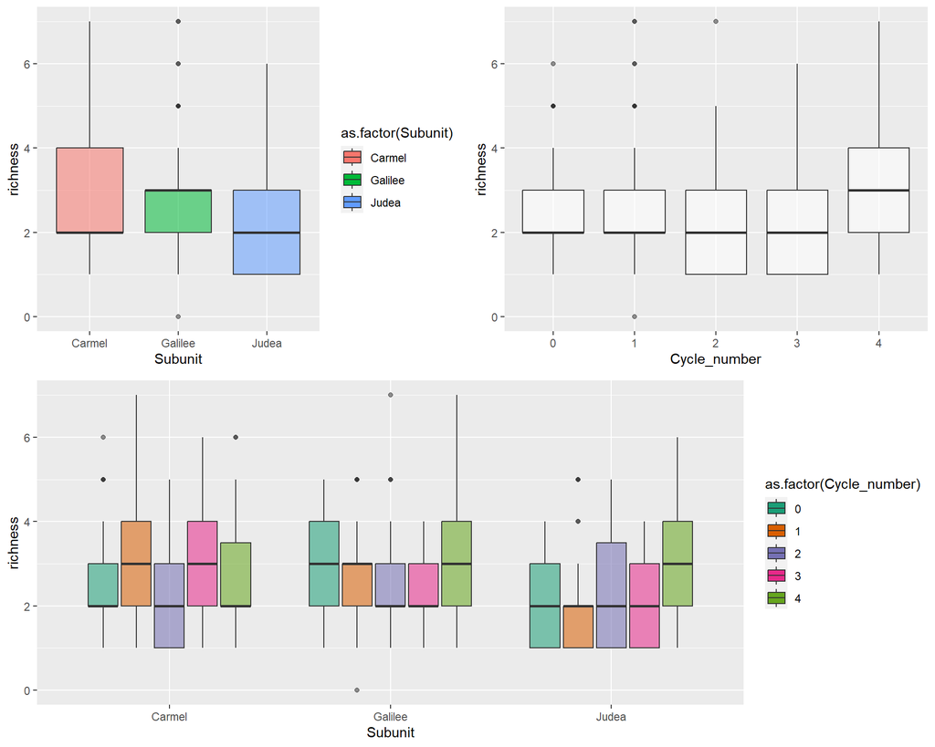

```r
plot_alpha_diversity(P, x_val = "Subunit", y_val = "richness", ylab_val = "richness", xlab_val = "Subunit", fill_val = "Subunit")
```

```r
col_names <- c("Cycle_number",  "Deployment.id_new",    "Unit", "Subunit",  "Site", "Settlements",  "Distance_rescaled", "Lon", "Lat", "year", "rescaled_Time.Diff", "sinus_Monitoring.Time.Diff", "cosinus_Monitoring.Time.Diff", "Transect", "Transect_with_date")

abu_by_spp.Maquis <- all.mammal.abundances[grepl("Mediterranean Maquis",Unit),]
spp <- abu_by_spp.Maquis[,c(27:39)]

# filter out species with zero counts
print(colSums(spp))
```

```
##    Canis aureus     Canis lupus   Capra nubiana  Equus hemionus  Gazella dorcas
##            6971              44               0               0               0
## Gazella gazella   Hyaena hyaena  Hystrix indica  Lepus capensis     Meles meles
##             406             298            3019              10             408
##   Oryx leucoryx      Sus scrofa   Vulpes vulpes
##               0           10124            1478
```

```
## Overlapping points were shifted along the y-axis to make them visible.
```

```
##
##  PIPING TO 2nd MVFACTOR
```

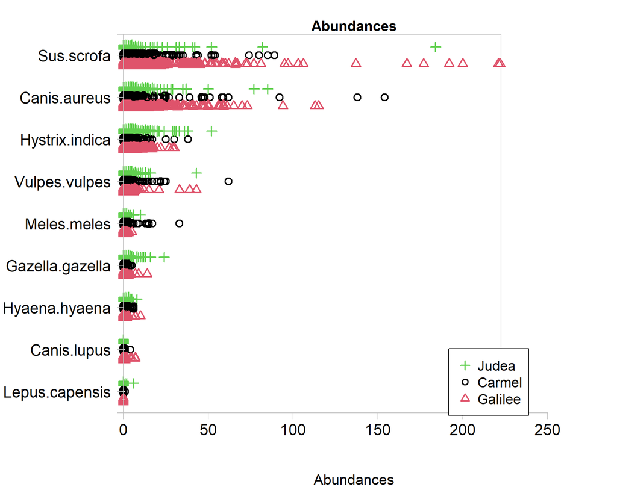

```r
spp <- spp[,.SD,.SDcols = colSums(spp)>0]
spp <- mvabund(spp)

plot(spp ~ P.anal$Subunit, overall.main="raw abundances", transformation = "no")
```

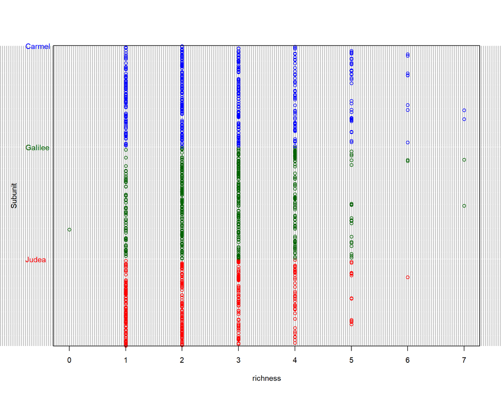

```r
my_cols <- c("blue", "darkgreen", "red")
dotchart(P.anal$richness, ylab = "Subunit",
         groups = P.anal$Subunit, gcolor = my_cols,
         color = my_cols[P.anal$Subunit],
         cex = 0.9,  pch = 1, xlab = "richness")
```

```r
kable(summary(P.anal[,.(richness, abundance, Subunit, rescaled_Time.Diff, cosinus_Monitoring.Time.Diff, sinus_Monitoring.Time.Diff, Site, Transect, Transect_with_date, Distance_rescaled)]))
```

|  | richness | abundance | Subunit | rescaled_Time.Diff | cosinus_Monitoring.Time.Diff | sinus_Monitoring.Time.Diff | Site | Transect | Transect_with_date | Distance_rescaled |
| --- | --- | --- | --- | --- | --- | --- | --- | --- | --- | --- |
|  | Min. :0.000 | Min. : 0.00 | Carmel :376 | Min. :-1.8927 | Min. :-0.99996 | Min. :-0.999990 | Goren : 87 | Goren Near : 45 | Kerem Maharal Far_19_05_2015: 10 | Min. :-0.9136 |
|  | 1st Qu.:2.000 | 1st Qu.: 4.00 | Galilee:417 | 1st Qu.:-0.9172 | 1st Qu.:-0.83907 | 1st Qu.:-0.602000 | Ein Yaakov : 85 | Ein Yaakov Near : 44 | Aderet Near_10_08_2021 : 9 | 1st Qu.:-0.8371 |
|  | Median :2.000 | Median : 10.00 | Judea :324 | Median :-0.1836 | Median :-0.04866 | Median : 0.000000 | Kfar Shamai: 84 | Goren Far : 42 | Beit Oren Far_07_07_2017 : 9 | Median :-0.6362 |
|  | Mean :2.569 | Mean : 20.37 | NA | Mean :-0.2623 | Mean :-0.08610 | Mean : 0.008294 | Margaliot : 82 | Kfar Shamai Far : 42 | Ein Yaakov Far_06_07_2021 : 9 | Mean :-0.5033 |
|  | 3rd Qu.:3.000 | 3rd Qu.: 24.00 | NA | 3rd Qu.: 0.5940 | 3rd Qu.: 0.56975 | 3rd Qu.: 0.733190 | Iftach : 79 | Kfar Shamai Near: 42 | Ein Yaakov Far_11_11_2015 : 9 | 3rd Qu.:-0.3237 |
|  | Max. :7.000 | Max. :341.00 | NA | Max. : 1.1755 | Max. : 1.00000 | Max. : 0.999990 | Nir Etzion : 77 | Margaliot Near : 42 | Ein Yaakov Near_03_06_2012 : 9 | Max. : 1.6119 |
|  | NA | NA | NA | NA | NA | NA | (Other) :623 | (Other) :860 | (Other) :1062 | NA |

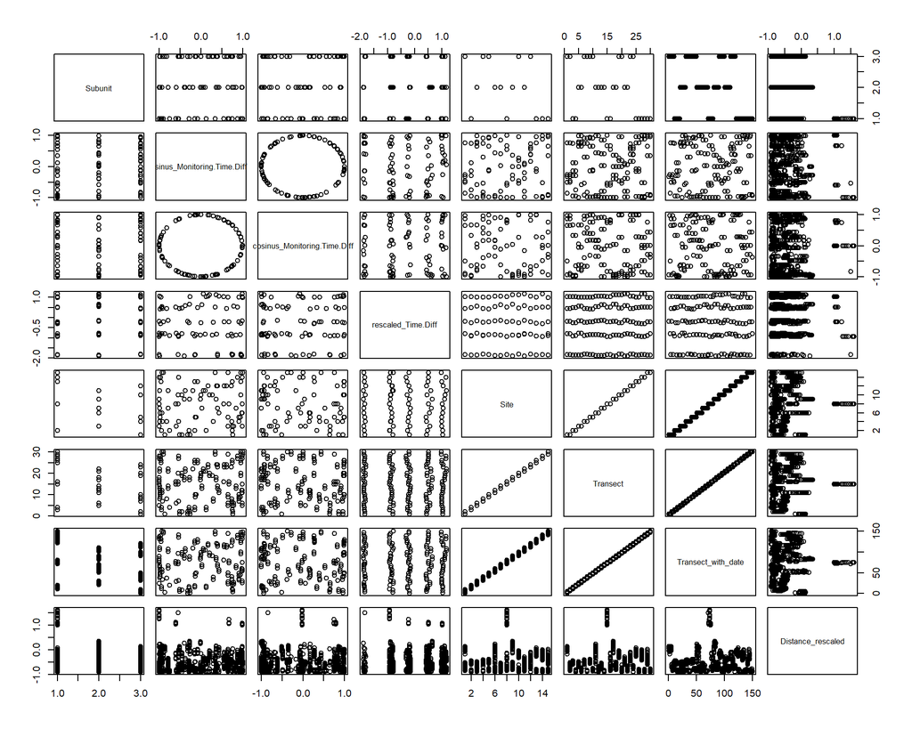

```r
pairs(P.anal[,lapply(X = .SD,FUN = as.numeric),.SDcols=c("Subunit","sinus_Monitoring.Time.Diff", "cosinus_Monitoring.Time.Diff", "rescaled_Time.Diff","Site","Transect", "Transect_with_date", "Distance_rescaled")])
```

```r
kable(cor(P.anal[,lapply(X = .SD,FUN = as.numeric),.SDcols=c("Subunit","sinus_Monitoring.Time.Diff", "cosinus_Monitoring.Time.Diff", "rescaled_Time.Diff","Site","Transect", "Transect_with_date", "Distance_rescaled")]))
```

|  | Subunit | sinus_Monitoring.Time.Diff | cosinus_Monitoring.Time.Diff | rescaled_Time.Diff | Site | Transect | Transect_with_date | Distance_rescaled |
| --- | --- | --- | --- | --- | --- | --- | --- | --- |
| Subunit | 1.0000000 | 0.0808235 | 0.1250776 | 0.0324596 | -0.3922386 | -0.3901787 | -0.3895513 | -0.1278084 |
| sinus_Monitoring.Time.Diff | 0.0808235 | 1.0000000 | 0.0926611 | 0.0071447 | 0.0360044 | 0.0345840 | 0.0366821 | -0.0592206 |
| cosinus_Monitoring.Time.Diff | 0.1250776 | 0.0926611 | 1.0000000 | 0.0589309 | -0.0782191 | -0.0774880 | -0.0767999 | -0.0119164 |
| rescaled_Time.Diff | 0.0324596 | 0.0071447 | 0.0589309 | 1.0000000 | -0.0128696 | -0.0125757 | -0.0165851 | -0.0556040 |
| Site | -0.3922386 | 0.0360044 | -0.0782191 | -0.0128696 | 1.0000000 | 0.9983334 | 0.9977772 | 0.0211274 |
| Transect | -0.3901787 | 0.0345840 | -0.0774880 | -0.0125757 | 0.9983334 | 1.0000000 | 0.9994624 | -0.0167655 |
| Transect_with_date | -0.3895513 | 0.0366821 | -0.0767999 | -0.0165851 | 0.9977772 | 0.9994624 | 1.0000000 | -0.0171086 |
| Distance_rescaled | -0.1278084 | -0.0592206 | -0.0119164 | -0.0556040 | 0.0211274 | -0.0167655 | -0.0171086 | 1.0000000 |

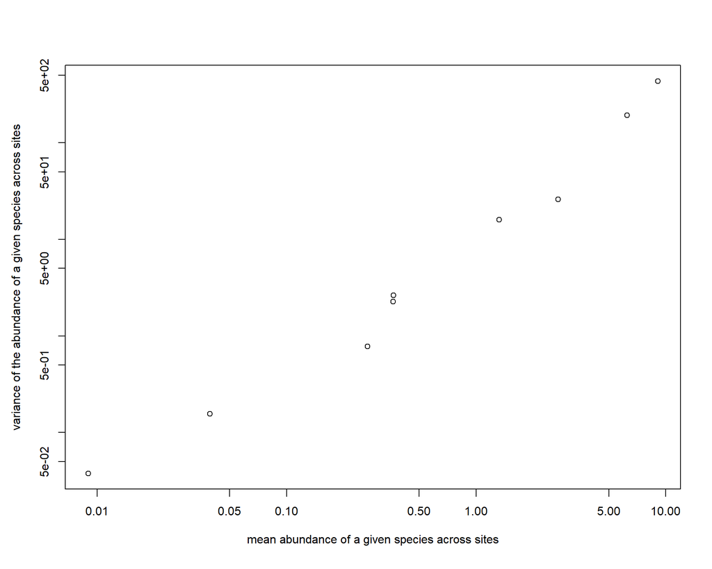

```r
meanvar.plot(spp, xlab = "mean abundance of a given species across sites", ylab = "variance of the abundance of a given species across sites")
```

#### Community analysis using package MVabund

Table of abundances per species by camera ID

```r
abundance_and_cameras <- as.data.table(abu_by_spp.Maquis[,c(5,27:39)])
dim(abundance_and_cameras)
```

```
## [1] 1117   14
```

```r
canisau <- abundance_and_cameras[,2] > 0
sum(canisau)
```

```
## [1] 678
```

```r
canislup <- abundance_and_cameras[,3] > 0
sum(canislup)
```

```
## [1] 20
```

```r
capra <- abundance_and_cameras[,4] > 0
sum(capra)
```

```
## [1] 0
```

```r
Equus <- abundance_and_cameras[,5] > 0
sum(Equus)
```

```
## [1] 0
```

```r
Gazellador <- abundance_and_cameras[,6] > 0
sum(Gazellador)
```

```
## [1] 0
```

```r
Gazellagaz <- abundance_and_cameras[,7] > 0
sum(Gazellagaz)
```

```
## [1] 141
```

```r
Hyaena <- abundance_and_cameras[,8] > 0
sum(Hyaena)
```

```
## [1] 153
```

```r
Hystrix <- abundance_and_cameras[,9] > 0
sum(Hystrix)
```

```
## [1] 599
```

```r
Lepus <- abundance_and_cameras[,10] > 0
sum(Lepus)
```

```
## [1] 4
```

```r
Meles <- abundance_and_cameras[,11] > 0
sum(Meles)
```

```
## [1] 178
```

```r
Oryx <- abundance_and_cameras[,12] > 0
sum(Oryx)
```

```
## [1] 0
```

```r
Sus <- abundance_and_cameras[,13] > 0
sum(Sus)
```

```
## [1] 703
```

```r
Vulpus <- abundance_and_cameras[,14] > 0
sum(Vulpus)
```

```
## [1] 394
```

1117 cameras. Species with a minimum of 20 cameras - Canis aureus, Canis lupus, Gazella gazella, Hyaena hyaena, Hystrix indica, Meles meles, Sus scorfa and Vulpus vulpus

```r
spp_no_rare <- abu_by_spp.Maquis[,27:39]
print(colSums(spp_no_rare))
```

```
##    Canis aureus     Canis lupus   Capra nubiana  Equus hemionus  Gazella dorcas
##            6971              44               0               0               0
## Gazella gazella   Hyaena hyaena  Hystrix indica  Lepus capensis     Meles meles
##             406             298            3019              10             408
##   Oryx leucoryx      Sus scrofa   Vulpes vulpes
##               0           10124            1478
```

```r
# filter out species with less than 20 individuals (rare species)
spp_no_rare <- spp_no_rare[,.SD,.SDcols = colSums(spp_no_rare)>=20]
#spp_no_rare <- spp_no_rare[,c(-2,-6)]
spp_no_rare <- mvabund(spp_no_rare)
print(colSums(spp_no_rare))
```

```
##    Canis.aureus     Canis.lupus Gazella.gazella   Hyaena.hyaena  Hystrix.indica
##            6971              44             406             298            3019
##     Meles.meles      Sus.scrofa   Vulpes.vulpes
##             408           10124            1478
```

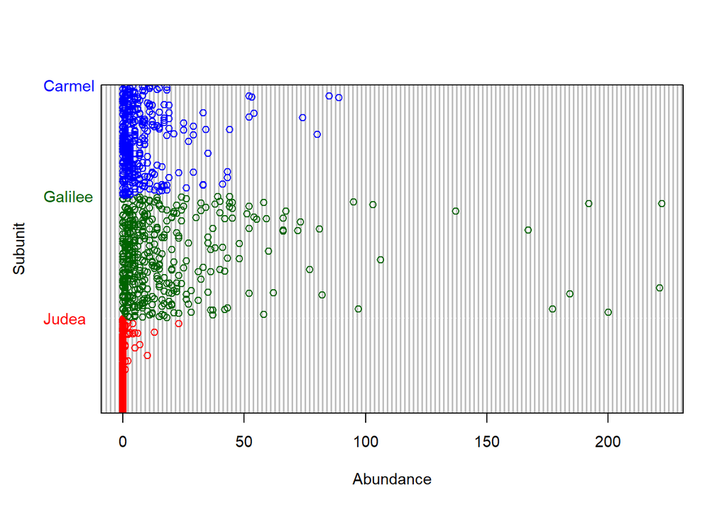

```r
#Sus scorfa abundance across subunit, sites and projectid
my_cols <- c("blue", "darkgreen", "red")
dotchart(P.anal$`Sus scrofa`, ylab = "Subunit",
         groups = P.anal$Subunit, gcolor = my_cols,
         color = my_cols[P.anal$Subunit],
         cex = 0.9,  pch = 1, xlab = "Abundance")
```

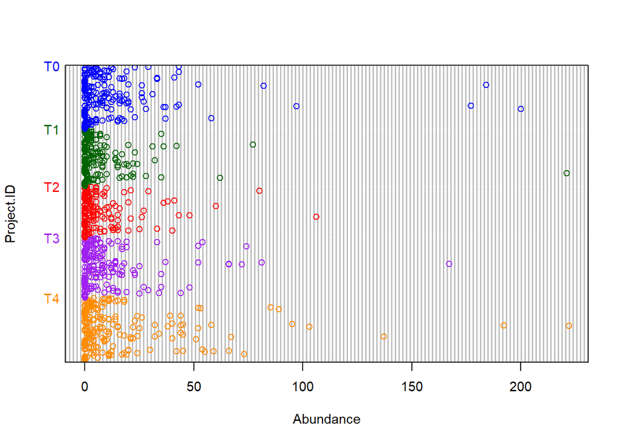

```r
P.anal$Project.ID <- as.factor(P.anal$Project.ID)
my_cols <- c("blue", "darkgreen", "red", "purple", "darkorange")
dotchart(P.anal$`Sus scrofa`, ylab = "Project.ID",
         groups = P.anal$Project.ID, gcolor = my_cols,
         color = my_cols[P.anal$Project.ID],
         cex = 0.9,  pch = 1, xlab = "Abundance")
```

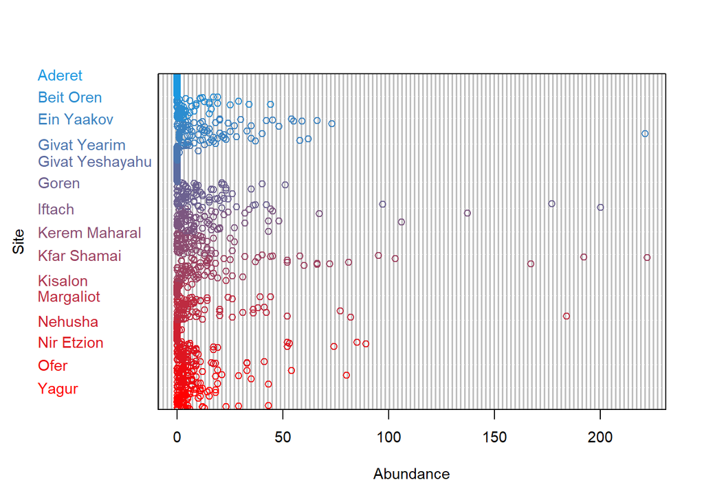

```r
fun_color_range <- colorRampPalette(c("#1b98e0", "red"))
my_cols <- fun_color_range(15)
dotchart(P.anal$`Sus scrofa`, ylab = "Site",
         groups = P.anal$Site, gcolor = my_cols,
         color = my_cols[P.anal$Site],
         cex = 0.9,  pch = 1, xlab = "Abundance")
```

Species with 20 individuals or more - Canis aureus, Canis lupus, Gazella gazella, Hyaena hyaena, Hystrix indica, Meles meles, Sus scorfa and Vulpus vulpus

Left with 8 species

```r
env_data <- abu_by_spp.Maquis[,..col_names]

mva_m0.po <- manyglm(formula = spp_no_rare ~ Distance_rescaled * rescaled_Time.Diff + cosinus_Monitoring.Time.Diff + sinus_Monitoring.Time.Diff, family = "poisson", data = env_data)

mva_m0.nb <- manyglm(formula = spp_no_rare ~ Distance_rescaled * rescaled_Time.Diff + cosinus_Monitoring.Time.Diff + sinus_Monitoring.Time.Diff, family = "negative.binomial", data = env_data)

aic_dt <- data.table(nb = mva_m0.nb$aic, po=mva_m0.po$aic)
colMeans(aic_dt)
```

```
##       nb       po
## 2979.663 8038.338
```

```r
print("POISSON")
```

```
## [1] "POISSON"
```

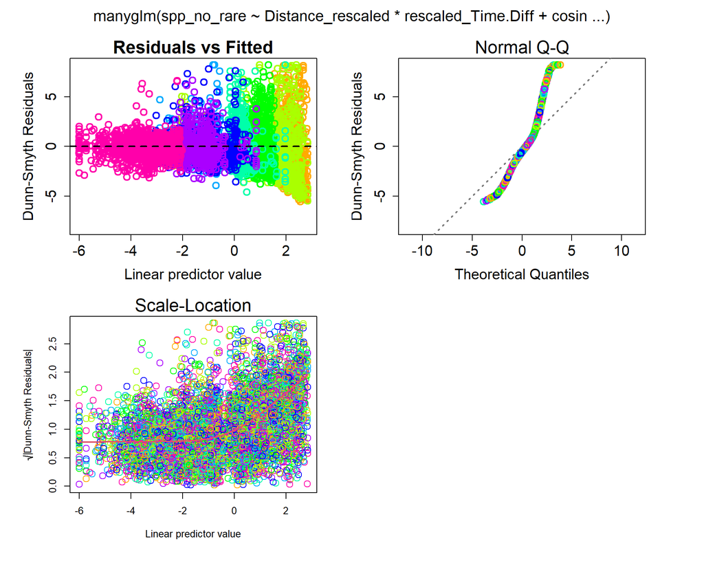

```r
plot(mva_m0.po, which=1:3)
```

```r
print("NEGATIVE BINOMIAL")
```

```
## [1] "NEGATIVE BINOMIAL"
```

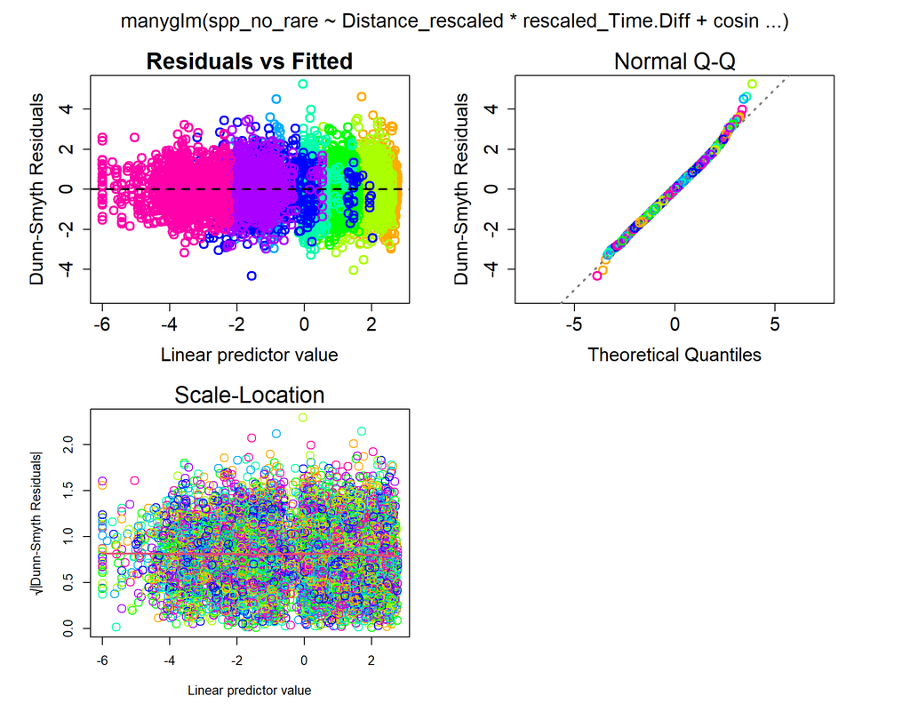

```r
plot(mva_m0.nb, which=1:3)
```

prefer negative binomial because standardized residuals are smaller.

```r
# mva_m0 <- mva_m0.po
# mva_m1 <- manyglm(formula = spp_no_rare ~ Distance_rescaled * rescaled_Time.Diff + dunes*rescaled_Time.Diff + Distance_rescaled:dunes + cos_td_rad + sin_td_rad + site, family = "poisson", data = env_data)
# aic_dt$po1 <- mva_m1$aic

mva_m0 <- mva_m0.nb
mva_m1 <- manyglm(formula = spp_no_rare ~ Distance_rescaled * rescaled_Time.Diff + cosinus_Monitoring.Time.Diff + sinus_Monitoring.Time.Diff + Site + Subunit, data = env_data)
aic_dt$nb1 <- mva_m1$aic
colMeans(aic_dt)
```

```
##       nb       po      nb1
## 2979.663 8038.338 2807.215
```

```r
mva_m2 <- manyglm(formula = spp_no_rare ~ Distance_rescaled * rescaled_Time.Diff + cosinus_Monitoring.Time.Diff + sinus_Monitoring.Time.Diff + Transect, data = env_data)
aic_dt$nb2 <- mva_m2$aic
colMeans(aic_dt)
```

```
##       nb       po      nb1      nb2
## 2979.663 8038.338 2807.215 2762.678
```

```r
mva_m3 <- manyglm(formula = spp_no_rare ~ Distance_rescaled * rescaled_Time.Diff + cosinus_Monitoring.Time.Diff + sinus_Monitoring.Time.Diff + Site, data = env_data)
aic_dt$nb3 <- mva_m2$aic
colMeans(aic_dt)
```

```
##       nb       po      nb1      nb2      nb3
## 2979.663 8038.338 2807.215 2762.678 2762.678
```

```r
mva_m4 <- manyglm(formula = spp_no_rare ~ Distance_rescaled * rescaled_Time.Diff + cosinus_Monitoring.Time.Diff + sinus_Monitoring.Time.Diff + Subunit, data = env_data)
aic_dt$nb4 <- mva_m2$aic
colMeans(aic_dt)
```

```
##       nb       po      nb1      nb2      nb3      nb4
## 2979.663 8038.338 2807.215 2762.678 2762.678 2762.678
```

Will proceed with subunit:

##Many GLM with subunit

```r
mva_m0.nb <- manyglm(formula = spp_no_rare ~ Distance_rescaled * rescaled_Time.Diff + cosinus_Monitoring.Time.Diff + sinus_Monitoring.Time.Diff + Subunit, family = "negative.binomial", data = env_data)
drop1(mva_m0.nb)
```

```
## Single term deletions
##
## Model:
## spp_no_rare ~ Distance_rescaled * rescaled_Time.Diff + cosinus_Monitoring.Time.Diff +
##     sinus_Monitoring.Time.Diff + Subunit
##                                      Df   AIC
## <none>                                  23014
## cosinus_Monitoring.Time.Diff          8 23051
## sinus_Monitoring.Time.Diff            8 23009
## Subunit                              16 23837
## Distance_rescaled:rescaled_Time.Diff  8 23026
```

Dropped sin time

```r
# mva_m2 <- manyglm(formula = spp_no_rare ~ Distance_rescaled + dunes*rescaled_Time.Diff + Distance_rescaled:dunes + cos_td_rad + sin_td_rad, family = "poisson", data = env_data)
mva_m2 <- manyglm(formula = spp_no_rare ~ Distance_rescaled * rescaled_Time.Diff + cosinus_Monitoring.Time.Diff + Subunit, family = "negative.binomial", data = env_data)
drop1(mva_m2)
```

```
## Single term deletions
##
## Model:
## spp_no_rare ~ Distance_rescaled * rescaled_Time.Diff + cosinus_Monitoring.Time.Diff +
##     Subunit
##                                      Df   AIC
## <none>                                  23009
## cosinus_Monitoring.Time.Diff          8 23045
## Subunit                              16 23828
## Distance_rescaled:rescaled_Time.Diff  8 23025
```

```r
# mva_m2 <- manyglm(formula = spp_no_rare ~ Distance_rescaled + dunes + rescaled_Time.Diff + Distance_rescaled:dunes + cos_td_rad + sin_td_rad, family = "poisson", data = env_data)
# mva_m2 <- manyglm(formula = spp_no_rare ~ Distance_rescaled + cosinus_Monitoring.Time.Diff + sinus_Monitoring.Time.Diff + Site, family = "negative.binomial", data = env_data)
# drop1(mva_m2)
```

```r
# mva_m2 <- manyglm(formula = spp_no_rare ~ Distance_rescaled + dunes + rescaled_Time.Diff + Distance_rescaled:dunes + cos_td_rad + sin_td_rad, family = "poisson", data = env_data)
# mva_m2 <- manyglm(formula = spp_no_rare ~ Distance_rescaled + sinus_Monitoring.Time.Diff + Site, family = "negative.binomial", data = env_data)
# drop1(mva_m2)
```

Final model includes Subunit, cosin time difference and the interaction between time and distance from settlement

```r
# mva_m2 <- manyglm(formula = spp_no_rare ~ Dunes*rescaled_Time.Diff + sinus_Monitoring.Time.Diff + Transect_with_date, data = env_data)
 # drop1(mva_m2)
```

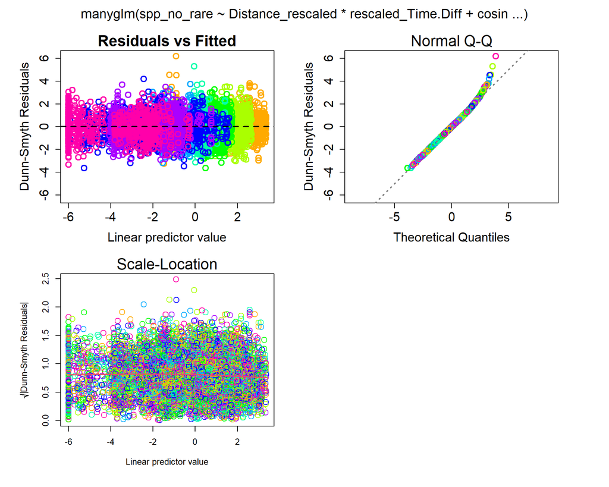

```r
plot(mva_m2, which=1:3)
```

```r
#summ_m2 <- summary(mva_m2)
#saveRDS(summ_m2, "output/summ_maquis_model_site.RDS")
summ_m2 <- readRDS("output/summ_maquis_model_site.RDS")
print(summ_m2)
```

```
##
## Test statistics:
##                                      wald value Pr(>wald)
## (Intercept)                              25.605     0.001 ***
## Distance_rescaled                        13.896     0.001 ***
## rescaled_Time.Diff                        4.126     0.106
## cosinus_Monitoring.Time.Diff              7.422     0.001 ***
## SubunitGalilee                           14.087     0.001 ***
## SubunitJudea                             24.436     0.001 ***
## Distance_rescaled:rescaled_Time.Diff      5.523     0.005 **
## ---
## Signif. codes:  0 '***' 0.001 '**' 0.01 '*' 0.05 '.' 0.1 ' ' 1
##
## Test statistic:  36.73, p-value: 0.001
## Arguments:
##  Test statistics calculated assuming response assumed to be uncorrelated
##  P-value calculated using 999 resampling iterations via pit.trap resampling (to account for correlation in testing).
```

```r
#anov_m2.uni <- anova(mva_m2, p.uni = "adjusted")
#saveRDS(anov_m2.uni, "output/anova_maquis_model_site.RDS")
anov_m2.uni <- readRDS("output/anova_maquis_model_site.RDS")
print(anov_m2.uni)
```

```
## Analysis of Deviance Table
##
## Model: spp_no_rare ~ Distance_rescaled * rescaled_Time.Diff + cosinus_Monitoring.Time.Diff + Subunit
##
## Multivariate test:
##                                      Res.Df Df.diff   Dev Pr(>Dev)
## (Intercept)                            1116
## Distance_rescaled                      1115       1 158.0    0.001 ***
## rescaled_Time.Diff                     1114       1  33.8    0.002 **
## cosinus_Monitoring.Time.Diff           1113       1 131.1    0.001 ***
## Subunit                                1111       2 844.9    0.001 ***
## Distance_rescaled:rescaled_Time.Diff   1110       1  32.3    0.003 **
## ---
## Signif. codes:  0 '***' 0.001 '**' 0.01 '*' 0.05 '.' 0.1 ' ' 1
##
## Univariate Tests:
##                                      Canis.aureus          Canis.lupus
##                                               Dev Pr(>Dev)         Dev Pr(>Dev)
## (Intercept)
## Distance_rescaled                          89.311    0.001        2.86    0.111
## rescaled_Time.Diff                          2.027    0.706       1.096    0.835
## cosinus_Monitoring.Time.Diff               37.437    0.001       0.075    0.963
## Subunit                                    19.789    0.006      34.104    0.001
## Distance_rescaled:rescaled_Time.Diff         3.32    0.312       0.034    0.979
##                                      Gazella.gazella          Hyaena.hyaena
##                                                  Dev Pr(>Dev)           Dev
## (Intercept)
## Distance_rescaled                             12.227    0.016         17.54
## rescaled_Time.Diff                             9.135    0.065         0.657
## cosinus_Monitoring.Time.Diff                  40.549    0.001        19.628
## Subunit                                       91.903    0.001        71.141
## Distance_rescaled:rescaled_Time.Diff           3.771    0.299         7.084
##                                               Hystrix.indica
##                                      Pr(>Dev)            Dev Pr(>Dev)
## (Intercept)
## Distance_rescaled                       0.004          4.298    0.102
## rescaled_Time.Diff                      0.882         17.427    0.005
## cosinus_Monitoring.Time.Diff            0.003              0    0.999
## Subunit                                 0.001         20.295    0.005
## Distance_rescaled:rescaled_Time.Diff    0.122          9.791    0.057
##                                      Meles.meles          Sus.scrofa
##                                              Dev Pr(>Dev)        Dev Pr(>Dev)
## (Intercept)
## Distance_rescaled                          8.019    0.059      6.114    0.068
## rescaled_Time.Diff                         0.091    0.945       3.27    0.515
## cosinus_Monitoring.Time.Diff               0.231    0.959     31.727    0.001
## Subunit                                   32.585    0.002    572.242    0.001
## Distance_rescaled:rescaled_Time.Diff       0.002    0.979      7.274    0.122
##                                      Vulpes.vulpes
##                                                Dev Pr(>Dev)
## (Intercept)
## Distance_rescaled                            17.64    0.004
## rescaled_Time.Diff                           0.122    0.945
## cosinus_Monitoring.Time.Diff                 1.497    0.719
## Subunit                                      2.821    0.434
## Distance_rescaled:rescaled_Time.Diff         1.029    0.710
## Arguments:
##  Test statistics calculated assuming uncorrelated response (for faster computation)
## P-value calculated using 999 iterations via PIT-trap resampling.
```

**Multivariate test shows that subunit, time, distance from settlements and timeXdistance affect species composition**

```r
coefp <- merge(data.table(t(coef(mva_m2)/log(2)),keep.rownames=TRUE), data.table(t(anov_m2.uni$uni.p), keep.rownames = TRUE), by = "rn") # coefficients are exponentiated because the link function used for poisson is log -> above 1 is positive and below 1 is negative
# add total species abundance
coefp <- merge(coefp,as.data.table(colSums(spp_no_rare),keep.rownames = TRUE), by.x = "rn", by.y = "V1")

colnames(coefp) <- c("SciName","Intercept.coef","Distance.coef","time_diff.coef","Cosin_time.coef","Galilee.coef","Judea.coef","Distance_time.coef","Intercept.p","Distance.p","time_diff.p","Cosin_time.p","Subunit.p","Distance_time.p","Species_abundance")

write.csv(coefp, "coefficients_Site_Maquis.csv")
```

```r
####Canis aureus####

Canis.aureus <- spp_no_rare[,"Canis.aureus"]
glm.Canis.aureus <- glm.nb(formula = Canis.aureus ~ Distance_rescaled + rescaled_Time.Diff + cosinus_Monitoring.Time.Diff + Site, data = env_data)
print(summary(glm.Canis.aureus))
```

```
##
## Call:
## glm.nb(formula = Canis.aureus ~ Distance_rescaled + rescaled_Time.Diff +
##     cosinus_Monitoring.Time.Diff + Site, data = env_data, init.theta = 0.3874865829,
##     link = log)
##
## Deviance Residuals:
##     Min       1Q   Median       3Q      Max
## -1.7465  -1.2179  -0.6465   0.0679   3.7902
##
## Coefficients:
##                              Estimate Std. Error z value Pr(>|z|)
## (Intercept)                   0.13230    0.21707   0.609 0.542200
## Distance_rescaled            -1.03728    0.14420  -7.193 6.33e-13 ***
## rescaled_Time.Diff           -0.00310    0.04860  -0.064 0.949143
## cosinus_Monitoring.Time.Diff -0.25188    0.08689  -2.899 0.003745 **
## SiteBeit Oren                 0.71271    0.29790   2.392 0.016736 *
## SiteEin Yaakov                1.69092    0.28253   5.985 2.16e-09 ***
## SiteGivat Yearim              1.09014    0.31079   3.508 0.000452 ***
## SiteGivat Yeshayahu          -0.76551    0.31365  -2.441 0.014660 *
## SiteGoren                     1.35792    0.27592   4.921 8.60e-07 ***
## SiteIftach                   -0.23953    0.29588  -0.810 0.418205
## SiteKerem Maharal             0.46764    0.31274   1.495 0.134840
## SiteKfar Shamai               1.33553    0.28909   4.620 3.84e-06 ***
## SiteKisalon                   0.98376    0.31268   3.146 0.001654 **
## SiteMargaliot                 1.15096    0.29249   3.935 8.32e-05 ***
## SiteNehusha                   0.71445    0.29414   2.429 0.015143 *
## SiteNir Etzion                0.85252    0.28637   2.977 0.002911 **
## SiteOfer                      1.68926    0.28493   5.929 3.06e-09 ***
## SiteYagur                     0.11416    0.29555   0.386 0.699312
## ---
## Signif. codes:  0 '***' 0.001 '**' 0.01 '*' 0.05 '.' 0.1 ' ' 1
##
## (Dispersion parameter for Negative Binomial(0.3875) family taken to be 1)
##
##     Null deviance: 1440.3  on 1116  degrees of freedom
## Residual deviance: 1133.8  on 1099  degrees of freedom
## AIC: 5477.4
##
## Number of Fisher Scoring iterations: 1
##
##
##               Theta:  0.3875
##           Std. Err.:  0.0206
##
##  2 x log-likelihood:  -5439.4360
```

```r
coef(glm.Canis.aureus)
```

```
##                  (Intercept)            Distance_rescaled
##                   0.13230360                  -1.03728194
##           rescaled_Time.Diff cosinus_Monitoring.Time.Diff
##                  -0.00309955                  -0.25188430
##                SiteBeit Oren               SiteEin Yaakov
##                   0.71271155                   1.69091881
##             SiteGivat Yearim          SiteGivat Yeshayahu
##                   1.09013769                  -0.76551388
##                    SiteGoren                   SiteIftach
##                   1.35791596                  -0.23952726
##            SiteKerem Maharal              SiteKfar Shamai
##                   0.46763507                   1.33552993
##                  SiteKisalon                SiteMargaliot
##                   0.98375599                   1.15096110
##                  SiteNehusha               SiteNir Etzion
##                   0.71445204                   0.85252488
##                     SiteOfer                    SiteYagur
##                   1.68925574                   0.11415527
```

```r
coef(mva_m2)
```

```
##                                      Canis.aureus Canis.lupus Gazella.gazella
## (Intercept)                             0.7836528  -6.6568237      -2.4838399
## Distance_rescaled                      -1.4509961  -1.2351726       1.9030344
## rescaled_Time.Diff                     -0.2145653   0.4338200       0.1655719
## cosinus_Monitoring.Time.Diff           -0.2993373   0.8389958       0.8634291
## SubunitGalilee                          0.3145271   3.8362076       1.8341808
## SubunitJudea                           -0.3647187  -8.8886543       3.0389989
## Distance_rescaled:rescaled_Time.Diff   -0.1939343  -0.1963558      -0.3172844
##                                      Hyaena.hyaena Hystrix.indica  Meles.meles
## (Intercept)                             -0.9247905    0.561179943 -0.752229612
## Distance_rescaled                        0.1630534   -0.269042397 -0.587767502
## rescaled_Time.Diff                      -0.3160072    0.007704151 -0.018706982
## cosinus_Monitoring.Time.Diff             0.4196223   -0.065554746  0.073613614
## SubunitGalilee                          -2.3879468    0.232072025 -1.165114581
## SubunitJudea                            -0.1874807    0.606274192 -1.039321245
## Distance_rescaled:rescaled_Time.Diff    -0.4406182   -0.387492686  0.007278454
##                                       Sus.scrofa Vulpes.vulpes
## (Intercept)                           1.82208786    0.37034817
## Distance_rescaled                    -0.39646487    0.46422533
## rescaled_Time.Diff                    0.07361119   -0.04014968
## cosinus_Monitoring.Time.Diff          0.01863800    0.06875367
## SubunitGalilee                        0.88245266    0.04265783
## SubunitJudea                         -3.32773363    0.27749662
## Distance_rescaled:rescaled_Time.Diff -0.20479750   -0.11397719
```

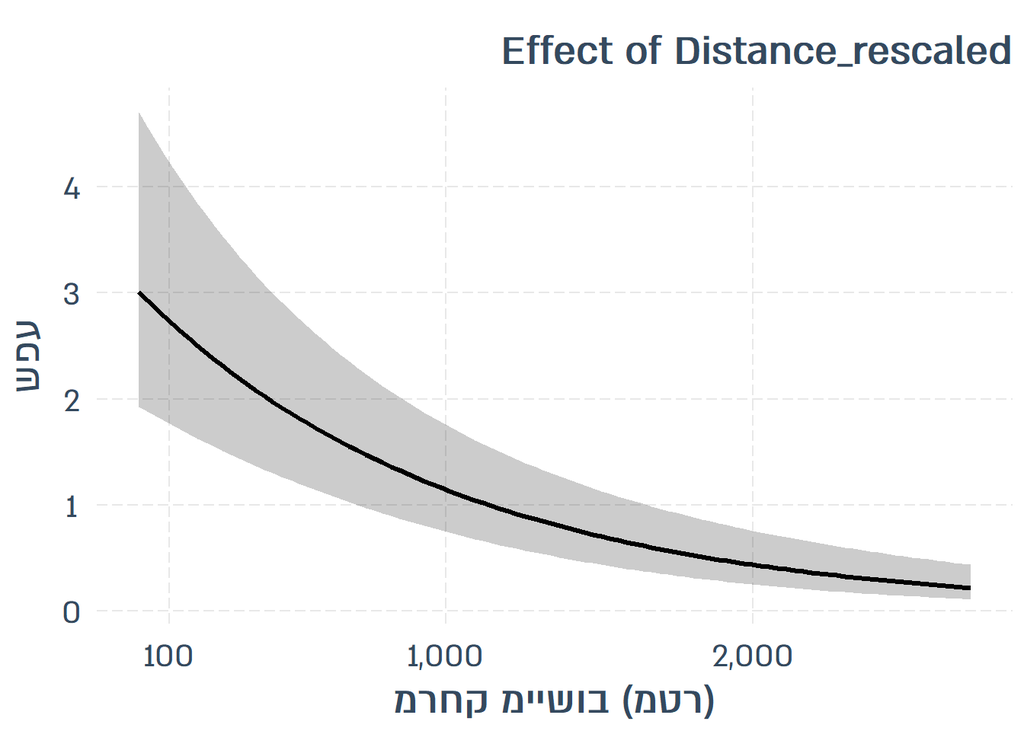

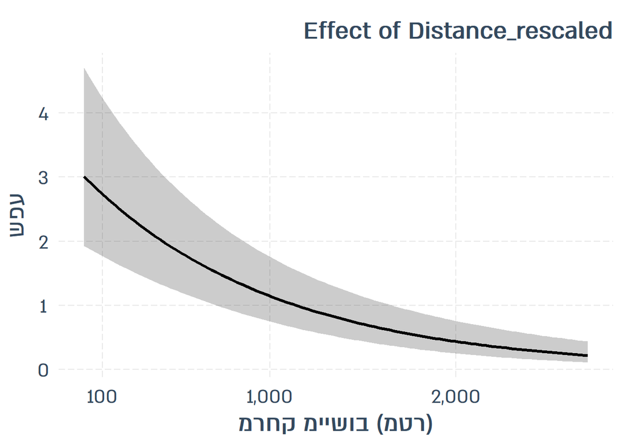

```r
source("functions/plot_model_effect_mammals_Maquis_and_Forest.R")
plot_model_effect(P.anal = env_data, m = glm.Canis.aureus, eff2plot = "Distance_rescaled", plot_points=FALSE, plot_residuals=FALSE, export_plot=TRUE, ylabel = NULL, fontname = "Almoni ML v5 AAA", fontsize=22, pdf_width=160, outpath = "output/maquis/")
```

```r
####Gazella gazella####

Gazella.gazella <- spp_no_rare[,"Gazella.gazella"]
glm.Gazella.gazella <- glm.nb(formula = Gazella.gazella ~ Distance_rescaled + rescaled_Time.Diff + cosinus_Monitoring.Time.Diff + Site, data = env_data)
print(summary(glm.Gazella.gazella))
```

```
##
## Call:
## glm.nb(formula = Gazella.gazella ~ Distance_rescaled + rescaled_Time.Diff +
##     cosinus_Monitoring.Time.Diff + Site, data = env_data, init.theta = 0.2833262366,
##     link = log)
##
## Deviance Residuals:
##     Min       1Q   Median       3Q      Max
## -1.3984  -0.5595  -0.1237   0.0000   2.8167
##
## Coefficients:
##                                Estimate Std. Error z value Pr(>|z|)
## (Intercept)                   1.369e+00  2.509e-01   5.455 4.89e-08 ***
## Distance_rescaled             1.701e+00  2.828e-01   6.016 1.79e-09 ***
## rescaled_Time.Diff            1.737e-01  1.011e-01   1.719 0.085564 .
## cosinus_Monitoring.Time.Diff  5.895e-01  1.584e-01   3.721 0.000199 ***
## SiteBeit Oren                -3.690e+01  7.853e+06   0.000 0.999996
## SiteEin Yaakov               -3.703e+01  7.279e+06   0.000 0.999996
## SiteGivat Yearim             -1.761e+00  4.606e-01  -3.823 0.000132 ***
## SiteGivat Yeshayahu          -9.362e-01  3.635e-01  -2.575 0.010013 *
## SiteGoren                    -3.765e+01  7.044e+06   0.000 0.999996
## SiteIftach                   -6.009e-01  3.775e-01  -1.592 0.111472
## SiteKerem Maharal            -2.907e+00  4.909e-01  -5.921 3.19e-09 ***
## SiteKfar Shamai              -2.744e+00  4.872e-01  -5.633 1.77e-08 ***
## SiteKisalon                  -1.716e+00  4.352e-01  -3.943 8.06e-05 ***
## SiteMargaliot                -3.692e+01  7.411e+06   0.000 0.999996
## SiteNehusha                  -1.421e+00  3.940e-01  -3.607 0.000310 ***
## SiteNir Etzion               -5.299e+00  1.070e+00  -4.952 7.34e-07 ***
## SiteOfer                     -4.122e+00  7.985e-01  -5.161 2.45e-07 ***
## SiteYagur                    -3.724e+01  7.713e+06   0.000 0.999996
## ---
## Signif. codes:  0 '***' 0.001 '**' 0.01 '*' 0.05 '.' 0.1 ' ' 1
##
## (Dispersion parameter for Negative Binomial(0.2833) family taken to be 1)
##
##     Null deviance: 747.04  on 1116  degrees of freedom
## Residual deviance: 337.70  on 1099  degrees of freedom
## AIC: 1105.6
##
## Number of Fisher Scoring iterations: 1
##
##
##               Theta:  0.2833
##           Std. Err.:  0.0388
##
##  2 x log-likelihood:  -1067.5850
```

```r
coef(glm.Gazella.gazella)
```

```
##                  (Intercept)            Distance_rescaled
##                    1.3687213                    1.7012666
##           rescaled_Time.Diff cosinus_Monitoring.Time.Diff
##                    0.1737436                    0.5895141
##                SiteBeit Oren               SiteEin Yaakov
##                  -36.8963765                  -37.0287932
##             SiteGivat Yearim          SiteGivat Yeshayahu
##                   -1.7610334                   -0.9362387
##                    SiteGoren                   SiteIftach
##                  -37.6478873                   -0.6008662
##            SiteKerem Maharal              SiteKfar Shamai
##                   -2.9068536                   -2.7445015
##                  SiteKisalon                SiteMargaliot
##                   -1.7157595                  -36.9231722
##                  SiteNehusha               SiteNir Etzion
##                   -1.4209898                   -5.2993400
##                     SiteOfer                    SiteYagur
##                   -4.1215505                  -37.2426408
```

```r
coef(mva_m2)
```

```
##                                      Canis.aureus Canis.lupus Gazella.gazella
## (Intercept)                             0.7836528  -6.6568237      -2.4838399
## Distance_rescaled                      -1.4509961  -1.2351726       1.9030344
## rescaled_Time.Diff                     -0.2145653   0.4338200       0.1655719
## cosinus_Monitoring.Time.Diff           -0.2993373   0.8389958       0.8634291
## SubunitGalilee                          0.3145271   3.8362076       1.8341808
## SubunitJudea                           -0.3647187  -8.8886543       3.0389989
## Distance_rescaled:rescaled_Time.Diff   -0.1939343  -0.1963558      -0.3172844
##                                      Hyaena.hyaena Hystrix.indica  Meles.meles
## (Intercept)                             -0.9247905    0.561179943 -0.752229612
## Distance_rescaled                        0.1630534   -0.269042397 -0.587767502
## rescaled_Time.Diff                      -0.3160072    0.007704151 -0.018706982
## cosinus_Monitoring.Time.Diff             0.4196223   -0.065554746  0.073613614
## SubunitGalilee                          -2.3879468    0.232072025 -1.165114581
## SubunitJudea                            -0.1874807    0.606274192 -1.039321245
## Distance_rescaled:rescaled_Time.Diff    -0.4406182   -0.387492686  0.007278454
##                                       Sus.scrofa Vulpes.vulpes
## (Intercept)                           1.82208786    0.37034817
## Distance_rescaled                    -0.39646487    0.46422533
## rescaled_Time.Diff                    0.07361119   -0.04014968
## cosinus_Monitoring.Time.Diff          0.01863800    0.06875367
## SubunitGalilee                        0.88245266    0.04265783
## SubunitJudea                         -3.32773363    0.27749662
## Distance_rescaled:rescaled_Time.Diff -0.20479750   -0.11397719
```

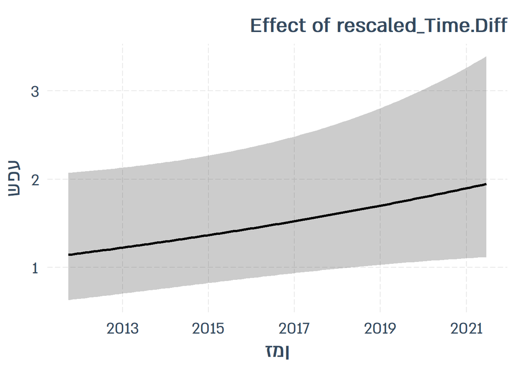

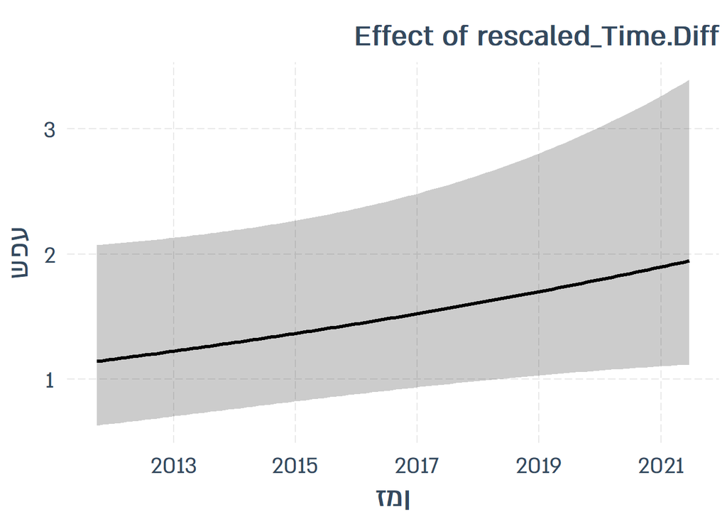

```r
plot_model_effect(P.anal = env_data, m = glm.Gazella.gazella, eff2plot = "rescaled_Time.Diff", plot_points=FALSE, plot_residuals=FALSE, export_plot=TRUE, ylabel = NULL, fontname = "Almoni ML v5 AAA", fontsize=22, pdf_width=160, outpath = "output/maquis/")
```

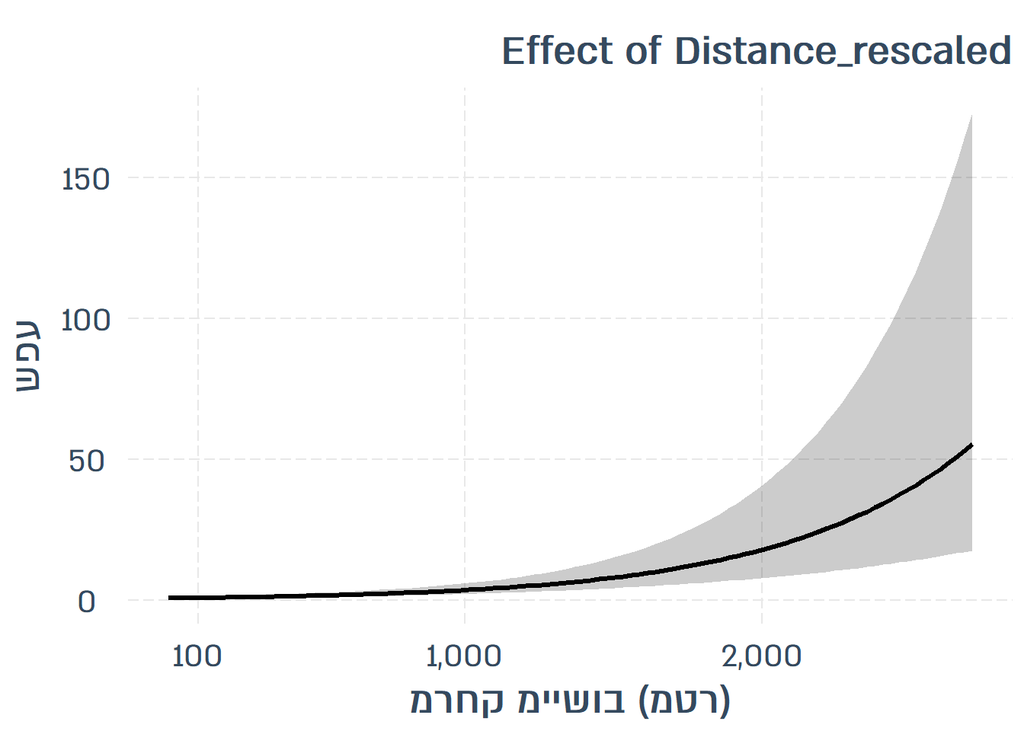

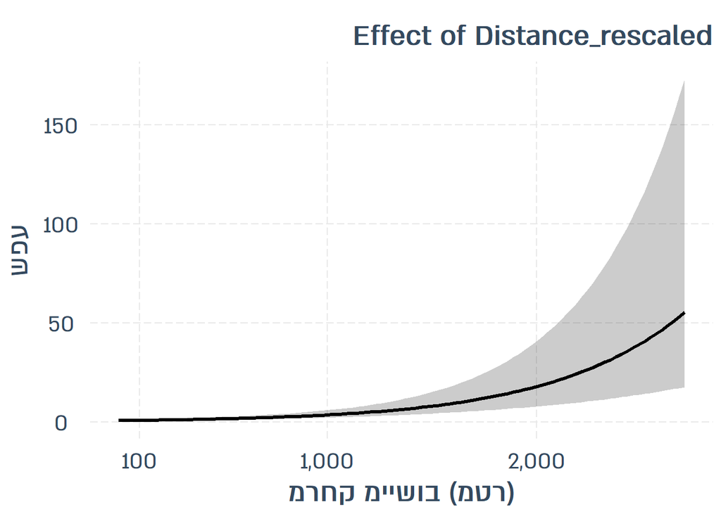

```r
plot_model_effect(P.anal = env_data, m = glm.Gazella.gazella, eff2plot = "Distance_rescaled", plot_points=FALSE, plot_residuals=FALSE, export_plot=TRUE, ylabel = NULL, fontname = "Almoni ML v5 AAA", fontsize=22, pdf_width=160, outpath = "output/maquis/")
```

```r
####Hyaena hyaena####

Hyaena.hyaena <- spp_no_rare[,"Hyaena.hyaena"]
glm.Hyaena.hyaena <- glm.nb(formula = Hyaena.hyaena ~ Distance_rescaled * rescaled_Time.Diff + cosinus_Monitoring.Time.Diff + Site, data = env_data)
print(summary(glm.Hyaena.hyaena))
```

```
##
## Call:
## glm.nb(formula = Hyaena.hyaena ~ Distance_rescaled * rescaled_Time.Diff +
##     cosinus_Monitoring.Time.Diff + Site, data = env_data, init.theta = 0.3289665235,
##     link = log)
##
## Deviance Residuals:
##    Min      1Q  Median      3Q     Max
## -1.183  -0.657  -0.423   0.000   2.435
##
## Coefficients:
##                                        Estimate Std. Error z value Pr(>|z|)
## (Intercept)                          -9.132e-01  2.906e-01  -3.143  0.00168 **
## Distance_rescaled                     3.491e-01  2.460e-01   1.419  0.15590
## rescaled_Time.Diff                   -3.370e-01  1.178e-01  -2.862  0.00421 **
## cosinus_Monitoring.Time.Diff          4.032e-01  1.482e-01   2.720  0.00652 **
## SiteBeit Oren                        -4.907e-02  4.345e-01  -0.113  0.91008
## SiteEin Yaakov                       -3.006e+01  4.088e+05   0.000  0.99994
## SiteGivat Yearim                      6.015e-01  4.092e-01   1.470  0.14156
## SiteGivat Yeshayahu                  -1.374e+00  5.055e-01  -2.718  0.00657 **
## SiteGoren                            -3.590e+00  1.072e+00  -3.349  0.00081 ***
## SiteIftach                           -6.941e-01  4.533e-01  -1.531  0.12571
## SiteKerem Maharal                    -2.505e-01  4.278e-01  -0.585  0.55823
## SiteKfar Shamai                      -3.005e+01  3.988e+05   0.000  0.99994
## SiteKisalon                           5.001e-01  4.100e-01   1.220  0.22255
## SiteMargaliot                        -2.991e+01  4.159e+05   0.000  0.99994
## SiteNehusha                          -1.232e+00  5.173e-01  -2.382  0.01720 *
## SiteNir Etzion                        2.241e-01  3.761e-01   0.596  0.55130
## SiteOfer                              4.732e-01  3.846e-01   1.230  0.21863
## SiteYagur                            -5.129e-01  4.369e-01  -1.174  0.24043
## Distance_rescaled:rescaled_Time.Diff -4.505e-01  1.610e-01  -2.798  0.00514 **
## ---
## Signif. codes:  0 '***' 0.001 '**' 0.01 '*' 0.05 '.' 0.1 ' ' 1
##
## (Dispersion parameter for Negative Binomial(0.329) family taken to be 1)
##
##     Null deviance: 644.94  on 1116  degrees of freedom
## Residual deviance: 425.22  on 1098  degrees of freedom
## AIC: 1161.5
##
## Number of Fisher Scoring iterations: 1
##
##
##               Theta:  0.3290
##           Std. Err.:  0.0537
##
##  2 x log-likelihood:  -1121.5250
```

```r
coef(glm.Hyaena.hyaena)
```

```
##                          (Intercept)                    Distance_rescaled
##                          -0.91320224                           0.34909622
##                   rescaled_Time.Diff         cosinus_Monitoring.Time.Diff
##                          -0.33700680                           0.40315862
##                        SiteBeit Oren                       SiteEin Yaakov
##                          -0.04907179                         -30.06320966
##                     SiteGivat Yearim                  SiteGivat Yeshayahu
##                           0.60152996                          -1.37381799
##                            SiteGoren                           SiteIftach
##                          -3.59008089                          -0.69410055
##                    SiteKerem Maharal                      SiteKfar Shamai
##                          -0.25048355                         -30.05032280
##                          SiteKisalon                        SiteMargaliot
##                           0.50010434                         -29.91031648
##                          SiteNehusha                       SiteNir Etzion
##                          -1.23236188                           0.22407097
##                             SiteOfer                            SiteYagur
##                           0.47315952                          -0.51289805
## Distance_rescaled:rescaled_Time.Diff
##                          -0.45052533
```

```r
coef(mva_m2)
```

```
##                                      Canis.aureus Canis.lupus Gazella.gazella
## (Intercept)                             0.7836528  -6.6568237      -2.4838399
## Distance_rescaled                      -1.4509961  -1.2351726       1.9030344
## rescaled_Time.Diff                     -0.2145653   0.4338200       0.1655719
## cosinus_Monitoring.Time.Diff           -0.2993373   0.8389958       0.8634291
## SubunitGalilee                          0.3145271   3.8362076       1.8341808
## SubunitJudea                           -0.3647187  -8.8886543       3.0389989
## Distance_rescaled:rescaled_Time.Diff   -0.1939343  -0.1963558      -0.3172844
##                                      Hyaena.hyaena Hystrix.indica  Meles.meles
## (Intercept)                             -0.9247905    0.561179943 -0.752229612
## Distance_rescaled                        0.1630534   -0.269042397 -0.587767502
## rescaled_Time.Diff                      -0.3160072    0.007704151 -0.018706982
## cosinus_Monitoring.Time.Diff             0.4196223   -0.065554746  0.073613614
## SubunitGalilee                          -2.3879468    0.232072025 -1.165114581
## SubunitJudea                            -0.1874807    0.606274192 -1.039321245
## Distance_rescaled:rescaled_Time.Diff    -0.4406182   -0.387492686  0.007278454
##                                       Sus.scrofa Vulpes.vulpes
## (Intercept)                           1.82208786    0.37034817
## Distance_rescaled                    -0.39646487    0.46422533
## rescaled_Time.Diff                    0.07361119   -0.04014968
## cosinus_Monitoring.Time.Diff          0.01863800    0.06875367
## SubunitGalilee                        0.88245266    0.04265783
## SubunitJudea                         -3.32773363    0.27749662
## Distance_rescaled:rescaled_Time.Diff -0.20479750   -0.11397719
```

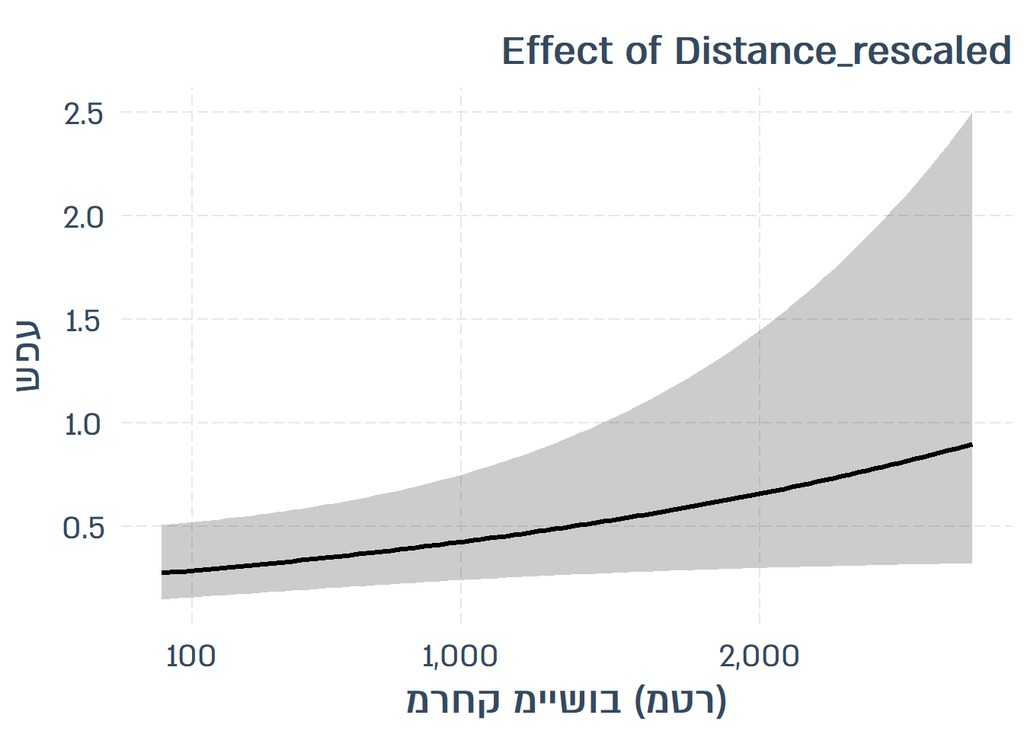

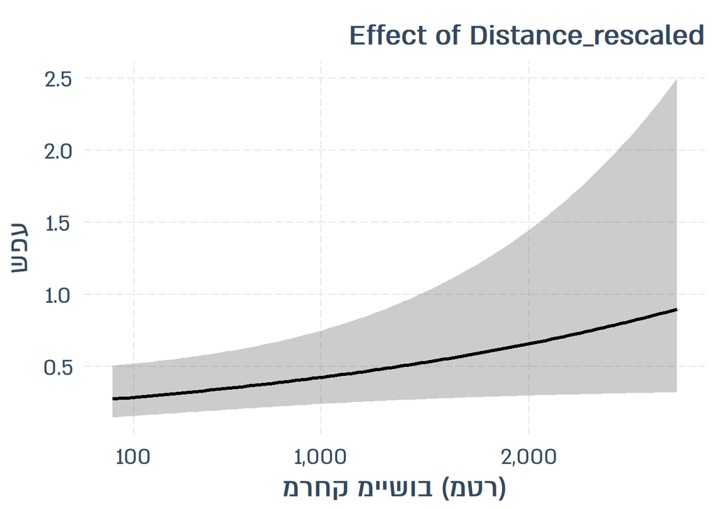

```r
plot_model_effect(P.anal = env_data, m = glm.Hyaena.hyaena, eff2plot = "Distance_rescaled", plot_points=FALSE, plot_residuals=FALSE, export_plot=TRUE, ylabel = NULL, fontname = "Almoni ML v5 AAA", fontsize=22, pdf_width=160, outpath = "output/maquis/")
```

```r
####Meles meles####

Meles.meles <- spp_no_rare[,"Meles.meles"]
glm.Meles.meles <- glm.nb(formula = Meles.meles ~ Distance_rescaled * rescaled_Time.Diff + cosinus_Monitoring.Time.Diff + Site, data = env_data)
print(summary(glm.Meles.meles))
```

```
##
## Call:
## glm.nb(formula = Meles.meles ~ Distance_rescaled * rescaled_Time.Diff +
##     cosinus_Monitoring.Time.Diff + Site, data = env_data, init.theta = 0.1889359821,
##     link = log)
##
## Deviance Residuals:
##     Min       1Q   Median       3Q      Max
## -0.9939  -0.6275  -0.5390  -0.3152   2.6116
##
## Coefficients:
##                                      Estimate Std. Error z value Pr(>|z|)
## (Intercept)                           -2.0005     0.4005  -4.995 5.88e-07 ***
## Distance_rescaled                     -0.6352     0.2623  -2.422   0.0154 *
## rescaled_Time.Diff                    -0.0646     0.1364  -0.474   0.6358
## cosinus_Monitoring.Time.Diff           0.3727     0.1619   2.302   0.0213 *
## SiteBeit Oren                          0.5935     0.5355   1.108   0.2677
## SiteEin Yaakov                        -1.4415     0.6928  -2.081   0.0375 *
## SiteGivat Yearim                       0.3480     0.5547   0.627   0.5304
## SiteGivat Yeshayahu                    0.1425     0.5235   0.272   0.7855
## SiteGoren                              0.1153     0.5109   0.226   0.8214
## SiteIftach                            -0.3040     0.5517  -0.551   0.5815
## SiteKerem Maharal                      1.0478     0.5263   1.991   0.0465 *
## SiteKfar Shamai                        1.0685     0.5222   2.046   0.0407 *
## SiteKisalon                           -1.3632     0.7787  -1.751   0.0800 .
## SiteMargaliot                          0.3423     0.5502   0.622   0.5338
## SiteNehusha                            0.4437     0.5288   0.839   0.4014
## SiteNir Etzion                         0.4241     0.5070   0.837   0.4029
## SiteOfer                               0.9736     0.5031   1.935   0.0530 .
## SiteYagur                              2.1635     0.4850   4.460 8.19e-06 ***
## Distance_rescaled:rescaled_Time.Diff  -0.1352     0.1960  -0.690   0.4904
## ---
## Signif. codes:  0 '***' 0.001 '**' 0.01 '*' 0.05 '.' 0.1 ' ' 1
##
## (Dispersion parameter for Negative Binomial(0.1889) family taken to be 1)
##
##     Null deviance: 580.10  on 1116  degrees of freedom
## Residual deviance: 481.81  on 1098  degrees of freedom
## AIC: 1452.6
##
## Number of Fisher Scoring iterations: 1
##
##
##               Theta:  0.1889
##           Std. Err.:  0.0241
##
##  2 x log-likelihood:  -1412.5940
```

```r
coef(glm.Meles.meles)
```

```
##                          (Intercept)                    Distance_rescaled
##                          -2.00052131                          -0.63522354
##                   rescaled_Time.Diff         cosinus_Monitoring.Time.Diff
##                          -0.06459685                           0.37269204
##                        SiteBeit Oren                       SiteEin Yaakov
##                           0.59353778                          -1.44153972
##                     SiteGivat Yearim                  SiteGivat Yeshayahu
##                           0.34802774                           0.14248741
##                            SiteGoren                           SiteIftach
##                           0.11533686                          -0.30404801
##                    SiteKerem Maharal                      SiteKfar Shamai
##                           1.04783452                           1.06851075
##                          SiteKisalon                        SiteMargaliot
##                          -1.36319446                           0.34235121
##                          SiteNehusha                       SiteNir Etzion
##                           0.44375014                           0.42406921
##                             SiteOfer                            SiteYagur
##                           0.97361906                           2.16347478
## Distance_rescaled:rescaled_Time.Diff
##                          -0.13520454
```

```r
coef(mva_m2)
```

```
##                                      Canis.aureus Canis.lupus Gazella.gazella
## (Intercept)                             0.7836528  -6.6568237      -2.4838399
## Distance_rescaled                      -1.4509961  -1.2351726       1.9030344
## rescaled_Time.Diff                     -0.2145653   0.4338200       0.1655719
## cosinus_Monitoring.Time.Diff           -0.2993373   0.8389958       0.8634291
## SubunitGalilee                          0.3145271   3.8362076       1.8341808
## SubunitJudea                           -0.3647187  -8.8886543       3.0389989
## Distance_rescaled:rescaled_Time.Diff   -0.1939343  -0.1963558      -0.3172844
##                                      Hyaena.hyaena Hystrix.indica  Meles.meles
## (Intercept)                             -0.9247905    0.561179943 -0.752229612
## Distance_rescaled                        0.1630534   -0.269042397 -0.587767502
## rescaled_Time.Diff                      -0.3160072    0.007704151 -0.018706982
## cosinus_Monitoring.Time.Diff             0.4196223   -0.065554746  0.073613614
## SubunitGalilee                          -2.3879468    0.232072025 -1.165114581
## SubunitJudea                            -0.1874807    0.606274192 -1.039321245
## Distance_rescaled:rescaled_Time.Diff    -0.4406182   -0.387492686  0.007278454
##                                       Sus.scrofa Vulpes.vulpes
## (Intercept)                           1.82208786    0.37034817
## Distance_rescaled                    -0.39646487    0.46422533
## rescaled_Time.Diff                    0.07361119   -0.04014968
## cosinus_Monitoring.Time.Diff          0.01863800    0.06875367
## SubunitGalilee                        0.88245266    0.04265783
## SubunitJudea                         -3.32773363    0.27749662
## Distance_rescaled:rescaled_Time.Diff -0.20479750   -0.11397719
```

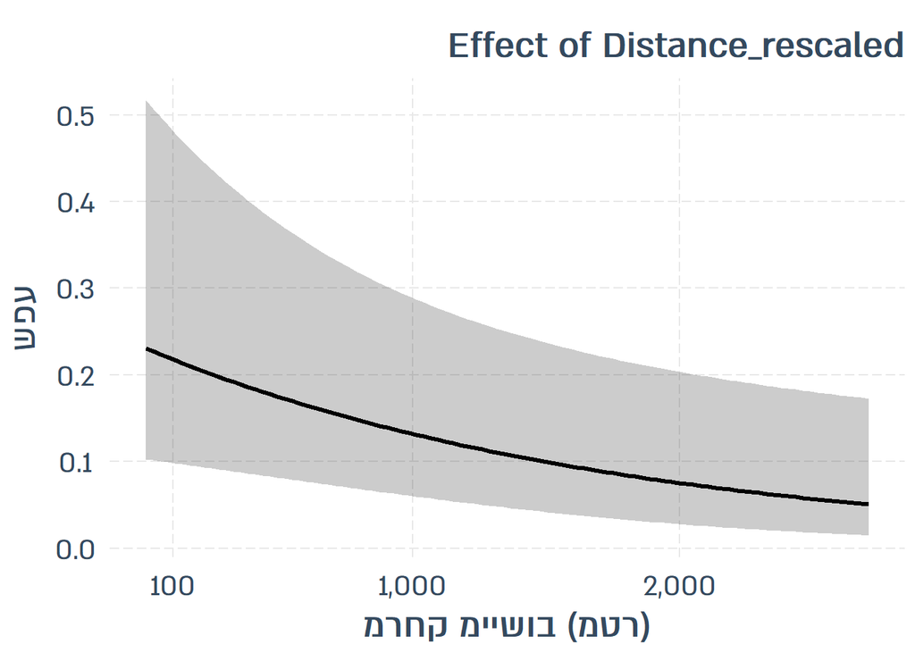

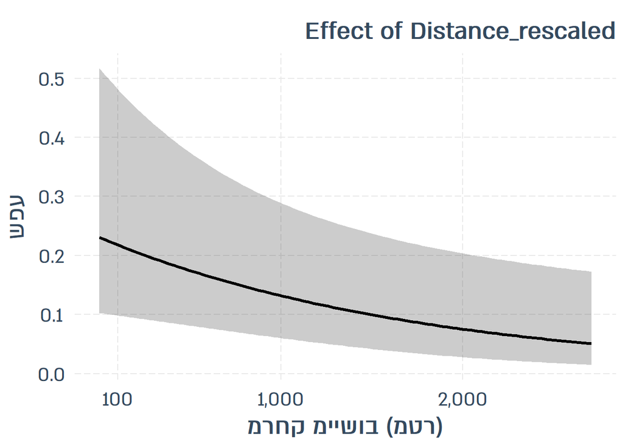

```r
plot_model_effect(P.anal = env_data, m = glm.Meles.meles, eff2plot = "Distance_rescaled", plot_points=FALSE, plot_residuals=FALSE, export_plot=TRUE, ylabel = NULL, fontname = "Almoni ML v5 AAA", fontsize=22, pdf_width=160, outpath = "output/maquis/")
```

```r
####Vulpus vulpus####

Vulpes.vulpes <- spp_no_rare[,"Vulpes.vulpes"]
glm.Vulpes.vulpes <- glm.nb(formula = Vulpes.vulpes ~ Distance_rescaled + rescaled_Time.Diff + cosinus_Monitoring.Time.Diff + Site, data = env_data)
print(summary(glm.Vulpes.vulpes))
```

```
##
## Call:
## glm.nb(formula = Vulpes.vulpes ~ Distance_rescaled + rescaled_Time.Diff +
##     cosinus_Monitoring.Time.Diff + Site, data = env_data, init.theta = 0.3068953754,
##     link = log)
##
## Deviance Residuals:
##     Min       1Q   Median       3Q      Max
## -1.2986  -0.9602  -0.6704  -0.1543   3.5218
##
## Coefficients:
##                              Estimate Std. Error z value Pr(>|z|)
## (Intercept)                   0.71399    0.23435   3.047 0.002314 **
## Distance_rescaled             0.33533    0.16337   2.053 0.040109 *
## rescaled_Time.Diff            0.11588    0.06130   1.890 0.058716 .
## cosinus_Monitoring.Time.Diff  0.06475    0.10915   0.593 0.553014
## SiteBeit Oren                -1.51041    0.38398  -3.934 8.37e-05 ***
## SiteEin Yaakov               -1.17786    0.34915  -3.373 0.000742 ***
## SiteGivat Yearim             -2.13669    0.45986  -4.646 3.38e-06 ***
## SiteGivat Yeshayahu           0.76126    0.32294   2.357 0.018412 *
## SiteGoren                    -1.17833    0.33422  -3.526 0.000423 ***
## SiteIftach                   -0.01873    0.32823  -0.057 0.954484
## SiteKerem Maharal             0.30567    0.33678   0.908 0.364072
## SiteKfar Shamai               0.58302    0.32535   1.792 0.073135 .
## SiteKisalon                  -1.72820    0.42177  -4.098 4.18e-05 ***
## SiteMargaliot                -1.60211    0.38010  -4.215 2.50e-05 ***
## SiteNehusha                  -0.47135    0.33974  -1.387 0.165315
## SiteNir Etzion               -1.40796    0.35600  -3.955 7.66e-05 ***
## SiteOfer                     -0.11803    0.32703  -0.361 0.718157
## SiteYagur                    -0.05436    0.32966  -0.165 0.869033
## ---
## Signif. codes:  0 '***' 0.001 '**' 0.01 '*' 0.05 '.' 0.1 ' ' 1
##
## (Dispersion parameter for Negative Binomial(0.3069) family taken to be 1)
##
##     Null deviance: 1020.03  on 1116  degrees of freedom
## Residual deviance:  822.95  on 1099  degrees of freedom
## AIC: 2935.2
##
## Number of Fisher Scoring iterations: 1
##
##
##               Theta:  0.3069
##           Std. Err.:  0.0237
##
##  2 x log-likelihood:  -2897.2410
```

```r
coef(glm.Vulpes.vulpes)
```

```
##                  (Intercept)            Distance_rescaled
##                   0.71398960                   0.33532676
##           rescaled_Time.Diff cosinus_Monitoring.Time.Diff
##                   0.11587943                   0.06475492
##                SiteBeit Oren               SiteEin Yaakov
##                  -1.51041470                  -1.17785871
##             SiteGivat Yearim          SiteGivat Yeshayahu
##                  -2.13669084                   0.76125523
##                    SiteGoren                   SiteIftach
##                  -1.17832816                  -0.01873417
##            SiteKerem Maharal              SiteKfar Shamai
##                   0.30567472                   0.58302195
##                  SiteKisalon                SiteMargaliot
##                  -1.72820136                  -1.60211394
##                  SiteNehusha               SiteNir Etzion
##                  -0.47135486                  -1.40795969
##                     SiteOfer                    SiteYagur
##                  -0.11803307                  -0.05435716
```

```r
coef(mva_m2)
```

```
##                                      Canis.aureus Canis.lupus Gazella.gazella
## (Intercept)                             0.7836528  -6.6568237      -2.4838399
## Distance_rescaled                      -1.4509961  -1.2351726       1.9030344
## rescaled_Time.Diff                     -0.2145653   0.4338200       0.1655719
## cosinus_Monitoring.Time.Diff           -0.2993373   0.8389958       0.8634291
## SubunitGalilee                          0.3145271   3.8362076       1.8341808
## SubunitJudea                           -0.3647187  -8.8886543       3.0389989
## Distance_rescaled:rescaled_Time.Diff   -0.1939343  -0.1963558      -0.3172844
##                                      Hyaena.hyaena Hystrix.indica  Meles.meles
## (Intercept)                             -0.9247905    0.561179943 -0.752229612
## Distance_rescaled                        0.1630534   -0.269042397 -0.587767502
## rescaled_Time.Diff                      -0.3160072    0.007704151 -0.018706982
## cosinus_Monitoring.Time.Diff             0.4196223   -0.065554746  0.073613614
## SubunitGalilee                          -2.3879468    0.232072025 -1.165114581
## SubunitJudea                            -0.1874807    0.606274192 -1.039321245
## Distance_rescaled:rescaled_Time.Diff    -0.4406182   -0.387492686  0.007278454
##                                       Sus.scrofa Vulpes.vulpes
## (Intercept)                           1.82208786    0.37034817
## Distance_rescaled                    -0.39646487    0.46422533
## rescaled_Time.Diff                    0.07361119   -0.04014968
## cosinus_Monitoring.Time.Diff          0.01863800    0.06875367
## SubunitGalilee                        0.88245266    0.04265783
## SubunitJudea                         -3.32773363    0.27749662
## Distance_rescaled:rescaled_Time.Diff -0.20479750   -0.11397719
```

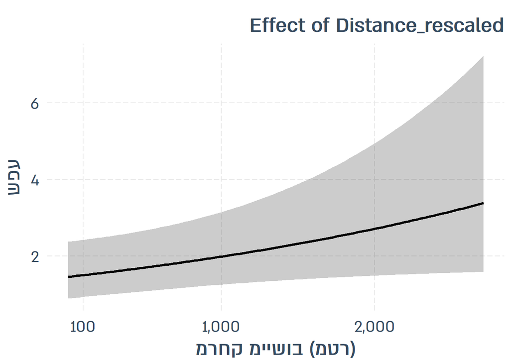

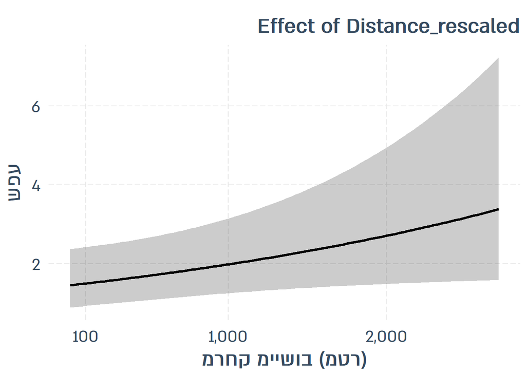

```r
plot_model_effect(P.anal = env_data, m = glm.Vulpes.vulpes, eff2plot = "Distance_rescaled", plot_points=FALSE, plot_residuals=FALSE, export_plot=TRUE, ylabel = NULL, fontname = "Almoni ML v5 AAA", fontsize=22, pdf_width=160, outpath = "output/maquis/")
```

```r
#####Hystrix indica####

Hystrix.indica <- spp_no_rare[,"Hystrix.indica"]
glm.Hystrix.indica <- glm.nb(formula = Hystrix.indica ~ Distance_rescaled * rescaled_Time.Diff + cosinus_Monitoring.Time.Diff + Site, data = env_data)
coef(glm.Hystrix.indica)
```

```
##                          (Intercept)                    Distance_rescaled
##                           0.45860383                          -0.52964293
##                   rescaled_Time.Diff         cosinus_Monitoring.Time.Diff
##                          -0.06413709                           0.04939549
##                        SiteBeit Oren                       SiteEin Yaakov
##                          -0.03206429                          -1.27421746
##                     SiteGivat Yearim                  SiteGivat Yeshayahu
##                           0.13990662                           1.00927181
##                            SiteGoren                           SiteIftach
##                           0.02617104                          -0.23012868
##                    SiteKerem Maharal                      SiteKfar Shamai
##                           0.60189664                           0.84253158
##                          SiteKisalon                        SiteMargaliot
##                           0.17540887                           0.61169662
##                          SiteNehusha                       SiteNir Etzion
##                           0.64288936                          -0.61634155
##                             SiteOfer                            SiteYagur
##                           0.35859865                          -0.90079811
## Distance_rescaled:rescaled_Time.Diff
##                          -0.35785205
```

```r
coef(mva_m2)
```

```
##                                      Canis.aureus Canis.lupus Gazella.gazella
## (Intercept)                             0.7836528  -6.6568237      -2.4838399
## Distance_rescaled                      -1.4509961  -1.2351726       1.9030344
## rescaled_Time.Diff                     -0.2145653   0.4338200       0.1655719
## cosinus_Monitoring.Time.Diff           -0.2993373   0.8389958       0.8634291
## SubunitGalilee                          0.3145271   3.8362076       1.8341808
## SubunitJudea                           -0.3647187  -8.8886543       3.0389989
## Distance_rescaled:rescaled_Time.Diff   -0.1939343  -0.1963558      -0.3172844
##                                      Hyaena.hyaena Hystrix.indica  Meles.meles
## (Intercept)                             -0.9247905    0.561179943 -0.752229612
## Distance_rescaled                        0.1630534   -0.269042397 -0.587767502
## rescaled_Time.Diff                      -0.3160072    0.007704151 -0.018706982
## cosinus_Monitoring.Time.Diff             0.4196223   -0.065554746  0.073613614
## SubunitGalilee                          -2.3879468    0.232072025 -1.165114581
## SubunitJudea                            -0.1874807    0.606274192 -1.039321245
## Distance_rescaled:rescaled_Time.Diff    -0.4406182   -0.387492686  0.007278454
##                                       Sus.scrofa Vulpes.vulpes
## (Intercept)                           1.82208786    0.37034817
## Distance_rescaled                    -0.39646487    0.46422533
## rescaled_Time.Diff                    0.07361119   -0.04014968
## cosinus_Monitoring.Time.Diff          0.01863800    0.06875367
## SubunitGalilee                        0.88245266    0.04265783
## SubunitJudea                         -3.32773363    0.27749662
## Distance_rescaled:rescaled_Time.Diff -0.20479750   -0.11397719
```

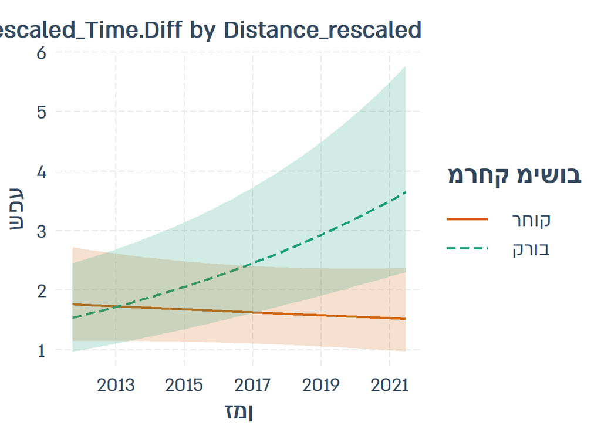

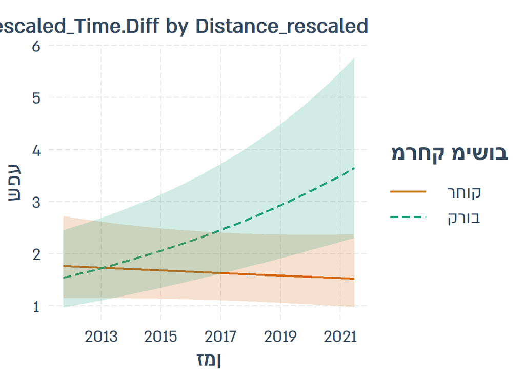

```r
source("functions/plot_interaction_mammals_Maquis_and_Forest.R")
plot_model_interaction(P.anal = env_data, m = glm.Hystrix.indica, eff2plot = "rescaled_Time.Diff", modvar2plot = "Distance_rescaled", plot_points=FALSE, plot_residuals=FALSE, export_plot=TRUE, ylabel = NULL, fontname = "Almoni ML v5 AAA",
fontsize=22, pdf_width=160, outpath = "output/maquis/")
```

```r
sd_distance <- sd(env_data$Distance_rescaled)
print(sd_distance)
```

```
## [1] 0.458914
```

```r
mean_distance <- mean(env_data$Distance_rescaled)
print(mean_distance)
```

```
## [1] -0.5033388
```

```r
#calculate +/1 1 SD
small_distance <- mean_distance - sd_distance
large_distance <- mean_distance + sd_distance

#Test whether temporal trend is different from zero
mm_rescaled_time <- emtrends(glm.Hystrix.indica, specs = "Distance_rescaled", var = "rescaled_Time.Diff", type = "response", at = list(Distance_rescaled = c(small_distance,large_distance)))
print(mm_rescaled_time)
```

```
##  Distance_rescaled rescaled_Time.Diff.trend     SE  df asymp.LCL asymp.UCL
##            -0.9623                   0.2802 0.0659 Inf     0.151    0.4094
##            -0.0444                  -0.0482 0.0671 Inf    -0.180    0.0833
##
## Results are averaged over the levels of: Site
## Confidence level used: 0.95
```

```r
test_results_mm_rescaled_time <- test(mm_rescaled_time, null = 0, adjust = "fdr")
print(test_results_mm_rescaled_time)
```

```
##  Distance_rescaled rescaled_Time.Diff.trend     SE  df z.ratio p.value
##            -0.9623                   0.2802 0.0659 Inf   4.250  <.0001
##            -0.0444                  -0.0482 0.0671 Inf  -0.719  0.4722
##
## Results are averaged over the levels of: Site
## P value adjustment: fdr method for 2 tests
```

```r
#Testing whether abundance is higher near or far from settlements
pairwise_distance <- emmeans(object = glm.Hystrix.indica, ~ Distance_rescaled*rescaled_Time.Diff, at = list(Distance_rescaled = c(small_distance,large_distance)))
print(pairwise_distance)
```

```
##  Distance_rescaled rescaled_Time.Diff emmean     SE  df asymp.LCL asymp.UCL
##            -0.9623             -0.262  0.981 0.0780 Inf     0.828      1.13
##            -0.0444             -0.262  0.581 0.0815 Inf     0.421      0.74
##
## Results are averaged over the levels of: Site
## Results are given on the log (not the response) scale.
## Confidence level used: 0.95
```

```r
test_results_distance <- test(pairs(pairwise_distance, by="rescaled_Time.Diff"), by=NULL, adjust="fdr")
print(test_results_distance)
```

```
##  contrast
##  (Distance_rescaled-0.962252785766932) - (Distance_rescaled-0.0444248306413041)
##  rescaled_Time.Diff estimate    SE  df z.ratio p.value
##              -0.262      0.4 0.124 Inf   3.233  0.0012
##
## Results are averaged over the levels of: Site
## Results are given on the log (not the response) scale.
```

##Many GLM with interactions

```r
mva_m0.nb <- manyglm(formula = spp_no_rare ~ Distance_rescaled * rescaled_Time.Diff + Subunit * Distance_rescaled + Subunit * rescaled_Time.Diff + cosinus_Monitoring.Time.Diff + sinus_Monitoring.Time.Diff, family = "negative.binomial", data = env_data)
drop1(mva_m0.nb)
```

```
## Single term deletions
##
## Model:
## spp_no_rare ~ Distance_rescaled * rescaled_Time.Diff + Subunit *
##     Distance_rescaled + Subunit * rescaled_Time.Diff + cosinus_Monitoring.Time.Diff +
##     sinus_Monitoring.Time.Diff
##                                      Df   AIC
## <none>                                  22814
## cosinus_Monitoring.Time.Diff          8 22853
## sinus_Monitoring.Time.Diff            8 22813
## Distance_rescaled:rescaled_Time.Diff  8 22814
## Distance_rescaled:Subunit            16 22900
## rescaled_Time.Diff:Subunit           16 22924
```

```r
mva_m1 <- manyglm(formula = spp_no_rare ~ Distance_rescaled * rescaled_Time.Diff + Subunit * Distance_rescaled + Subunit * rescaled_Time.Diff + cosinus_Monitoring.Time.Diff, family = "negative.binomial", data = env_data)
drop1(mva_m1)
```

```
## Single term deletions
##
## Model:
## spp_no_rare ~ Distance_rescaled * rescaled_Time.Diff + Subunit *
##     Distance_rescaled + Subunit * rescaled_Time.Diff + cosinus_Monitoring.Time.Diff
##                                      Df   AIC
## <none>                                  22813
## cosinus_Monitoring.Time.Diff          8 22851
## Distance_rescaled:rescaled_Time.Diff  8 22815
## Distance_rescaled:Subunit            16 22897
## rescaled_Time.Diff:Subunit           16 22920
```

```r
mva_m1 <- manyglm(formula = spp_no_rare ~ Subunit * Distance_rescaled + Subunit * rescaled_Time.Diff + cosinus_Monitoring.Time.Diff, family = "negative.binomial", data = env_data)
drop1(mva_m1)
```

```
## Single term deletions
##
## Model:
## spp_no_rare ~ Subunit * Distance_rescaled + Subunit * rescaled_Time.Diff +
##     cosinus_Monitoring.Time.Diff
##                              Df   AIC
## <none>                          22815
## cosinus_Monitoring.Time.Diff  8 22850
## Subunit:Distance_rescaled    16 22912
## Subunit:rescaled_Time.Diff   16 22919
```

Model includes cosin time, interaction between subunit and time and subunit and distance

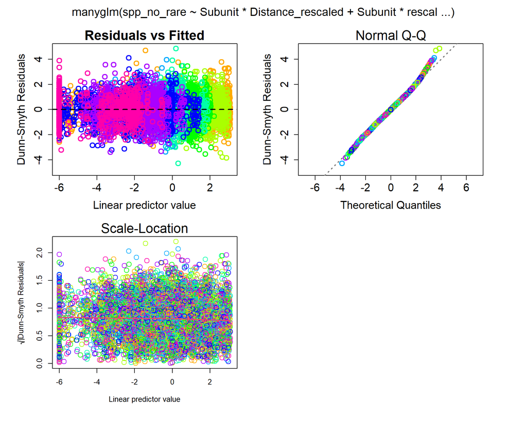

```r
plot(mva_m1, which=1:3)
```

```r
#summ_m2 <- summary(mva_m1)
#saveRDS(summ_m2, "output/summ_maquis_model_subunit.RDS")
summ_m2 <- readRDS("output/summ_maquis_model_subunit.RDS")
print(summ_m2)
```

```
##
## Test statistics:
##                                   wald value Pr(>wald)
## (Intercept)                           25.768     0.001 ***
## SubunitGalilee                         7.995     0.001 ***
## SubunitJudea                          14.892     0.001 ***
## Distance_rescaled                     12.740     0.001 ***
## rescaled_Time.Diff                     7.723     0.001 ***
## cosinus_Monitoring.Time.Diff           7.453     0.001 ***
## SubunitGalilee:Distance_rescaled       5.768     0.002 **
## SubunitJudea:Distance_rescaled        10.044     0.001 ***
## SubunitGalilee:rescaled_Time.Diff      6.877     0.001 ***
## SubunitJudea:rescaled_Time.Diff        7.906     0.001 ***
## ---
## Signif. codes:  0 '***' 0.001 '**' 0.01 '*' 0.05 '.' 0.1 ' ' 1
##
## Test statistic:  34.44, p-value: 0.001
## Arguments:
##  Test statistics calculated assuming response assumed to be uncorrelated
##  P-value calculated using 999 resampling iterations via pit.trap resampling (to account for correlation in testing).
```

```r
#anov_m2.uni <- anova(mva_m1, p.uni = "adjusted")
#saveRDS(anov_m2.uni, "output/anova_maquis_model_subunit.RDS")
anov_m2.uni <- readRDS("output/anova_maquis_model_subunit.RDS")
print(anov_m2.uni)
```

```
## Analysis of Deviance Table
##
## Model: spp_no_rare ~ Subunit * Distance_rescaled + Subunit * rescaled_Time.Diff + cosinus_Monitoring.Time.Diff
##
## Multivariate test:
##                              Res.Df Df.diff   Dev Pr(>Dev)
## (Intercept)                    1116
## Subunit                        1114       2 863.6    0.001 ***
## Distance_rescaled              1113       1 199.4    0.001 ***
## rescaled_Time.Diff             1112       1  55.7    0.001 ***
## cosinus_Monitoring.Time.Diff   1111       1  49.2    0.001 ***
## Subunit:Distance_rescaled      1109       2 138.5    0.001 ***
## Subunit:rescaled_Time.Diff     1107       2 135.8    0.001 ***
## ---
## Signif. codes:  0 '***' 0.001 '**' 0.01 '*' 0.05 '.' 0.1 ' ' 1
##
## Univariate Tests:
##                              Canis.aureus          Canis.lupus
##                                       Dev Pr(>Dev)         Dev Pr(>Dev)
## (Intercept)
## Subunit                            36.167    0.001      33.343    0.001
## Distance_rescaled                  92.681    0.001       1.134    0.517
## rescaled_Time.Diff                  6.789    0.104       1.291    0.759
## cosinus_Monitoring.Time.Diff       12.928    0.028       2.367    0.617
## Subunit:Distance_rescaled          19.085    0.007         0.7    0.241
## Subunit:rescaled_Time.Diff         43.537    0.001       4.213    0.487
##                              Gazella.gazella          Hyaena.hyaena
##                                          Dev Pr(>Dev)           Dev Pr(>Dev)
## (Intercept)
## Subunit                               60.391    0.001        92.277    0.001
## Distance_rescaled                     56.968    0.001          9.28    0.025
## rescaled_Time.Diff                    10.739    0.025         0.496    0.895
## cosinus_Monitoring.Time.Diff          25.716    0.001         6.914    0.146
## Subunit:Distance_rescaled              4.176    0.194        12.171    0.012
## Subunit:rescaled_Time.Diff             0.989    0.716           2.5    0.704
##                              Hystrix.indica          Meles.meles
##                                         Dev Pr(>Dev)         Dev Pr(>Dev)
## (Intercept)
## Subunit                              22.772    0.001      32.007    0.001
## Distance_rescaled                     0.472    0.517       8.625    0.025
## rescaled_Time.Diff                   17.991    0.012       0.042    0.928
## cosinus_Monitoring.Time.Diff          0.783    0.911       0.252    0.969
## Subunit:Distance_rescaled            41.145    0.001      19.296    0.007
## Subunit:rescaled_Time.Diff            1.771    0.716       3.351    0.637
##                              Sus.scrofa          Vulpes.vulpes
##                                     Dev Pr(>Dev)           Dev Pr(>Dev)
## (Intercept)
## Subunit                           582.6    0.001         4.074    0.282
## Distance_rescaled                12.569    0.025        17.674    0.015
## rescaled_Time.Diff               18.183    0.012         0.123    0.928
## cosinus_Monitoring.Time.Diff      0.001    0.980          0.21    0.969
## Subunit:Distance_rescaled        23.227    0.006        18.657    0.007
## Subunit:rescaled_Time.Diff       74.121    0.001         5.291    0.439
## Arguments:
##  Test statistics calculated assuming uncorrelated response (for faster computation)
## P-value calculated using 999 iterations via PIT-trap resampling.
```

```r
coefp <- merge(data.table(t(coef(mva_m1)/log(2)),keep.rownames=TRUE), data.table(t(anov_m2.uni$uni.p), keep.rownames = TRUE), by = "rn") # coefficients are exponentiated because the link function used for poisson is log -> above 1 is positive and below 1 is negative
# add total species abundance
coefp <- merge(coefp,as.data.table(colSums(spp_no_rare),keep.rownames = TRUE), by.x = "rn", by.y = "V1")

colnames(coefp) <- c("SciName","Intercept.coef","Galilee.coef","Judea.coef","Distance.coef","Time_diff.coef","cosin_time.coef","Galilee_distance.coef","Judea_distance.coef","Galilee_time.coef","Judea_time.coef","Intercept.p","Subunit.p","Distance.p","Time_diff.p","Cosin_time.p","Subunit_distance.p","Subunit_time.p","Species_abundance")

write.csv(coefp, "coefficients_Subunit_interactions_Maquis.csv")
```

```r
#####Canis aureus####

Canis.aureus <- spp_no_rare[,"Canis.aureus"]
glm.Canis.aureus <- glm.nb(formula = Canis.aureus ~ Subunit * Distance_rescaled + Subunit * rescaled_Time.Diff + cosinus_Monitoring.Time.Diff, data = env_data)
coef(glm.Canis.aureus)
```

```
##                       (Intercept)                    SubunitGalilee
##                         0.7379764                         0.2887068
##                      SubunitJudea                 Distance_rescaled
##                        -1.0561383                        -1.0768661
##                rescaled_Time.Diff      cosinus_Monitoring.Time.Diff
##                        -0.4959726                        -0.3461529
##  SubunitGalilee:Distance_rescaled    SubunitJudea:Distance_rescaled
##                        -0.4936521                        -1.6603072
## SubunitGalilee:rescaled_Time.Diff   SubunitJudea:rescaled_Time.Diff
##                         0.7092476                         0.5938064
```

```r
coef(mva_m2)
```

```
##                                      Canis.aureus Canis.lupus Gazella.gazella
## (Intercept)                             0.7836528  -6.6568237      -2.4838399
## Distance_rescaled                      -1.4509961  -1.2351726       1.9030344
## rescaled_Time.Diff                     -0.2145653   0.4338200       0.1655719
## cosinus_Monitoring.Time.Diff           -0.2993373   0.8389958       0.8634291
## SubunitGalilee                          0.3145271   3.8362076       1.8341808
## SubunitJudea                           -0.3647187  -8.8886543       3.0389989
## Distance_rescaled:rescaled_Time.Diff   -0.1939343  -0.1963558      -0.3172844
##                                      Hyaena.hyaena Hystrix.indica  Meles.meles
## (Intercept)                             -0.9247905    0.561179943 -0.752229612
## Distance_rescaled                        0.1630534   -0.269042397 -0.587767502
## rescaled_Time.Diff                      -0.3160072    0.007704151 -0.018706982
## cosinus_Monitoring.Time.Diff             0.4196223   -0.065554746  0.073613614
## SubunitGalilee                          -2.3879468    0.232072025 -1.165114581
## SubunitJudea                            -0.1874807    0.606274192 -1.039321245
## Distance_rescaled:rescaled_Time.Diff    -0.4406182   -0.387492686  0.007278454
##                                       Sus.scrofa Vulpes.vulpes
## (Intercept)                           1.82208786    0.37034817
## Distance_rescaled                    -0.39646487    0.46422533
## rescaled_Time.Diff                    0.07361119   -0.04014968
## cosinus_Monitoring.Time.Diff          0.01863800    0.06875367
## SubunitGalilee                        0.88245266    0.04265783
## SubunitJudea                         -3.32773363    0.27749662
## Distance_rescaled:rescaled_Time.Diff -0.20479750   -0.11397719
```

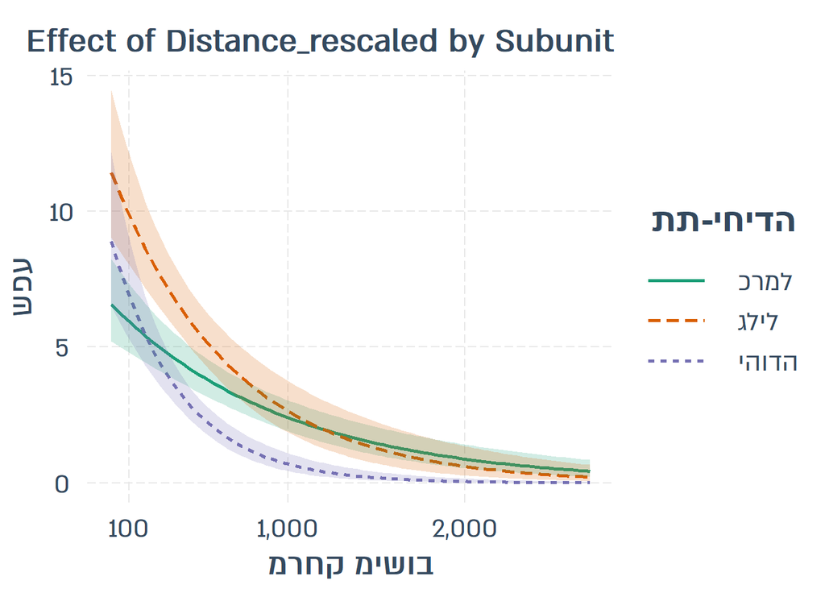

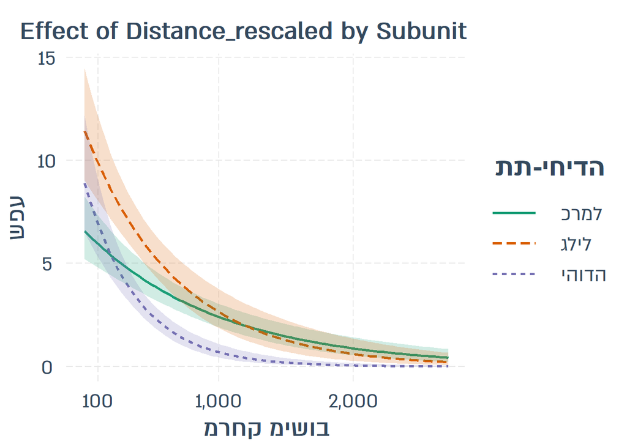

```r
source("functions/plot_interaction_mammals_Maquis_and_Forest.R")

plot_model_interaction(P.anal = env_data, m = glm.Canis.aureus, eff2plot = "Distance_rescaled", modvar2plot = "Subunit", plot_points=FALSE, plot_residuals=FALSE, export_plot=TRUE, ylabel = NULL, fontname = "Almoni ML v5 AAA",
fontsize=22, pdf_width=160, outpath = "output/maquis/")
```

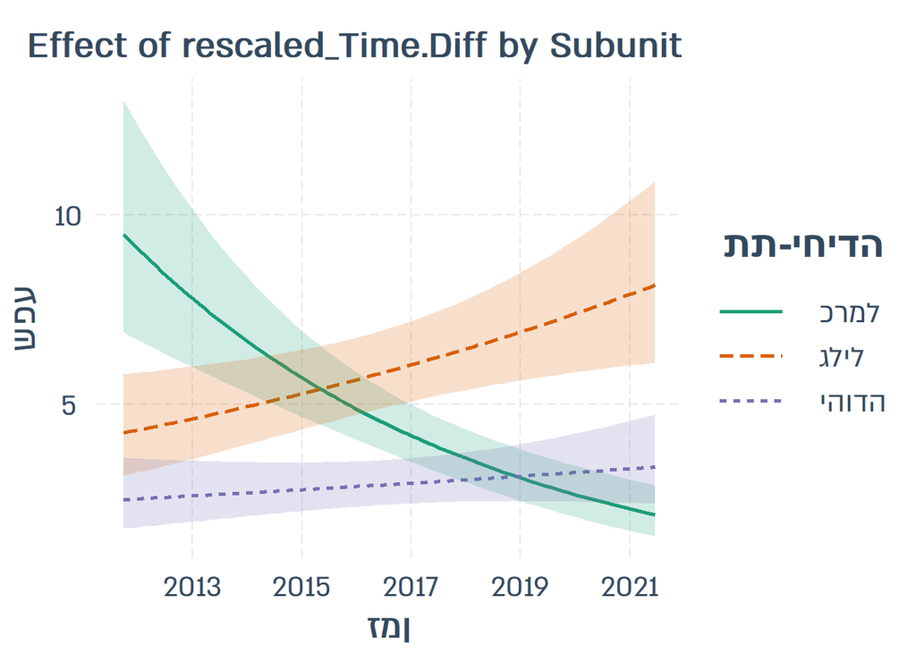

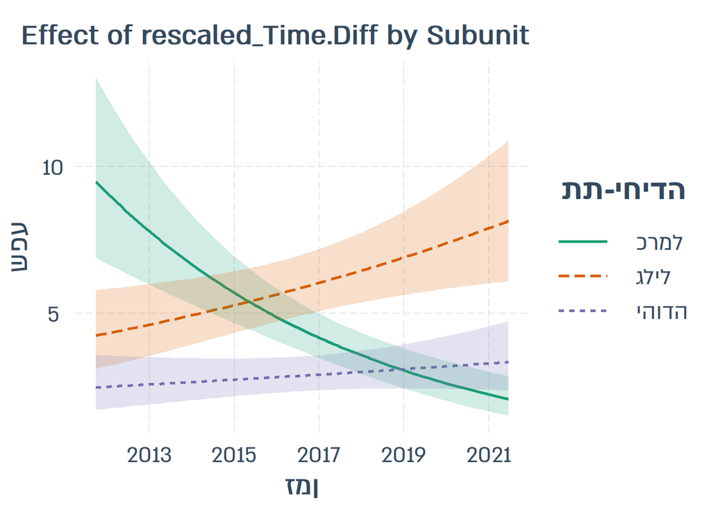

```r
plot_model_interaction(P.anal = env_data, m = glm.Canis.aureus, eff2plot = "rescaled_Time.Diff", modvar2plot = "Subunit", plot_points=FALSE, plot_residuals=FALSE, export_plot=TRUE, ylabel = NULL, fontname = "Almoni ML v5 AAA",
fontsize=22, pdf_width=160, outpath = "output/maquis/")
```

```r
#Test whether temporal trend is different from zero
print("Test whether temporal trend is different from zero")
```

```
## [1] "Test whether temporal trend is different from zero"
```

```r
mm_rescaled_time <- emtrends(glm.Canis.aureus, specs = "Subunit", var = "rescaled_Time.Diff", type = "response")
print(mm_rescaled_time)
```

```
##  Subunit rescaled_Time.Diff.trend     SE  df asymp.LCL asymp.UCL
##  Carmel                   -0.4960 0.0876 Inf   -0.6676    -0.324
##  Galilee                   0.2133 0.0816 Inf    0.0533     0.373
##  Judea                     0.0978 0.0974 Inf   -0.0931     0.289
##
## Confidence level used: 0.95
```

```r
test_results_mm_rescaled_time <- test(mm_rescaled_time, null = 0, adjust = "fdr")
print(test_results_mm_rescaled_time)
```

```
##  Subunit rescaled_Time.Diff.trend     SE  df z.ratio p.value
##  Carmel                   -0.4960 0.0876 Inf  -5.663  <.0001
##  Galilee                   0.2133 0.0816 Inf   2.613  0.0134
##  Judea                     0.0978 0.0974 Inf   1.004  0.3153
##
## P value adjustment: fdr method for 3 tests
```

```r
#Test whether spatial trend is different from zero
print("Test whether spatial trend is different from zero")
```

```
## [1] "Test whether spatial trend is different from zero"
```

```r
mm_rescaled_distance <- emtrends(glm.Canis.aureus, specs = "Subunit", var = "Distance_rescaled", type = "response")
print(mm_rescaled_distance)
```

```
##  Subunit Distance_rescaled.trend    SE  df asymp.LCL asymp.UCL
##  Carmel                    -1.08 0.159 Inf     -1.39    -0.765
##  Galilee                   -1.57 0.257 Inf     -2.08    -1.066
##  Judea                     -2.74 0.354 Inf     -3.43    -2.043
##
## Confidence level used: 0.95
```

```r
test_results_mm_distance <- test(mm_rescaled_distance, null = 0, adjust = "fdr")
print(test_results_mm_distance)
```

```
##  Subunit Distance_rescaled.trend    SE  df z.ratio p.value
##  Carmel                    -1.08 0.159 Inf  -6.759  <.0001
##  Galilee                   -1.57 0.257 Inf  -6.100  <.0001
##  Judea                     -2.74 0.354 Inf  -7.725  <.0001
##
## P value adjustment: fdr method for 3 tests
```

```r
#Compare spatial trends among subunits
print("Compare spatial trends among subunits")
```

```
## [1] "Compare spatial trends among subunits"
```

```r
pairwise_distance <- emmeans(object = glm.Canis.aureus, ~ Subunit*Distance_rescaled)
print(pairwise_distance)
```

```
##  Subunit Distance_rescaled emmean     SE  df asymp.LCL asymp.UCL
##  Carmel             -0.503   1.44 0.0919 Inf      1.26      1.62
##  Galilee            -0.503   1.79 0.0889 Inf      1.62      1.97
##  Judea              -0.503   1.06 0.1042 Inf      0.86      1.27
##
## Results are given on the log (not the response) scale.
## Confidence level used: 0.95
```

```r
test_results_distance <- test(pairs(pairwise_distance, by="Distance_rescaled"), by=NULL, adjust="fdr")
print(test_results_distance)
```

```
##  contrast         Distance_rescaled estimate    SE  df z.ratio p.value
##  Carmel - Galilee            -0.503   -0.351 0.128 Inf  -2.743  0.0067
##  Carmel - Judea              -0.503    0.376 0.139 Inf   2.711  0.0067
##  Galilee - Judea             -0.503    0.727 0.140 Inf   5.204  <.0001
##
## Results are given on the log (not the response) scale.
## P value adjustment: fdr method for 3 tests
```

```r
#####Hystrix indica####

Hystrix.indica <- spp_no_rare[,"Hystrix.indica"]
glm.Hystrix.indica <- glm.nb(formula = Hystrix.indica ~ Subunit * Distance_rescaled + Subunit * rescaled_Time.Diff + cosinus_Monitoring.Time.Diff, data = env_data)
summary(glm.Hystrix.indica)
```

```
##
## Call:
## glm.nb(formula = Hystrix.indica ~ Subunit * Distance_rescaled +
##     Subunit * rescaled_Time.Diff + cosinus_Monitoring.Time.Diff,
##     data = env_data, init.theta = 0.4028111892, link = log)
##
## Deviance Residuals:
##     Min       1Q   Median       3Q      Max
## -1.5583  -1.2303  -0.5464   0.1358   3.1233
##
## Coefficients:
##                                   Estimate Std. Error z value Pr(>|z|)
## (Intercept)                        0.85541    0.10742   7.963 1.68e-15 ***
## SubunitGalilee                    -0.06300    0.20344  -0.310  0.75679
## SubunitJudea                      -0.69582    0.23328  -2.983  0.00286 **
## Distance_rescaled                  0.32578    0.13876   2.348  0.01889 *
## rescaled_Time.Diff                 0.30195    0.08675   3.480  0.00050 ***
## cosinus_Monitoring.Time.Diff      -0.19146    0.08162  -2.346  0.01899 *
## SubunitGalilee:Distance_rescaled  -0.46150    0.28653  -1.611  0.10726
## SubunitJudea:Distance_rescaled    -2.27715    0.35563  -6.403 1.52e-10 ***
## SubunitGalilee:rescaled_Time.Diff -0.16600    0.12063  -1.376  0.16879
## SubunitJudea:rescaled_Time.Diff   -0.08044    0.12467  -0.645  0.51880
## ---
## Signif. codes:  0 '***' 0.001 '**' 0.01 '*' 0.05 '.' 0.1 ' ' 1
##
## (Dispersion parameter for Negative Binomial(0.4028) family taken to be 1)
##
##     Null deviance: 1166.1  on 1116  degrees of freedom
## Residual deviance: 1075.9  on 1107  degrees of freedom
## AIC: 4433.8
##
## Number of Fisher Scoring iterations: 1
##
##
##               Theta:  0.4028
##           Std. Err.:  0.0245
##
##  2 x log-likelihood:  -4411.7900
```

**Interaction of subunit with time is not significant - will be dropped from H. indica model**

```r
glm.Hystrix.indica <- glm.nb(formula = Hystrix.indica ~ Subunit * Distance_rescaled + rescaled_Time.Diff + cosinus_Monitoring.Time.Diff, data = env_data)
summary(glm.Hystrix.indica)
```

```
##
## Call:
## glm.nb(formula = Hystrix.indica ~ Subunit * Distance_rescaled +
##     rescaled_Time.Diff + cosinus_Monitoring.Time.Diff, data = env_data,
##     init.theta = 0.4018098414, link = log)
##
## Deviance Residuals:
##     Min       1Q   Median       3Q      Max
## -1.5446  -1.2182  -0.5649   0.1539   3.2922
##
## Coefficients:
##                                  Estimate Std. Error z value Pr(>|z|)
## (Intercept)                       0.82151    0.10519   7.810 5.73e-15 ***
## SubunitGalilee                    0.00744    0.19850   0.037  0.97010
## SubunitJudea                     -0.65891    0.23035  -2.860  0.00423 **
## Distance_rescaled                 0.29731    0.13844   2.148  0.03174 *
## rescaled_Time.Diff                0.21144    0.04902   4.314 1.61e-05 ***
## cosinus_Monitoring.Time.Diff     -0.15609    0.07729  -2.020  0.04343 *
## SubunitGalilee:Distance_rescaled -0.42307    0.28597  -1.479  0.13903
## SubunitJudea:Distance_rescaled   -2.22784    0.35518  -6.272 3.55e-10 ***
## ---
## Signif. codes:  0 '***' 0.001 '**' 0.01 '*' 0.05 '.' 0.1 ' ' 1
##
## (Dispersion parameter for Negative Binomial(0.4018) family taken to be 1)
##
##     Null deviance: 1164.2  on 1116  degrees of freedom
## Residual deviance: 1076.0  on 1109  degrees of freedom
## AIC: 4431.6
##
## Number of Fisher Scoring iterations: 1
##
##
##               Theta:  0.4018
##           Std. Err.:  0.0244
##
##  2 x log-likelihood:  -4413.5610
```

```r
coef(glm.Hystrix.indica)
```

```
##                      (Intercept)                   SubunitGalilee
##                      0.821514189                      0.007440017
##                     SubunitJudea                Distance_rescaled
##                     -0.658913418                      0.297311123
##               rescaled_Time.Diff     cosinus_Monitoring.Time.Diff
##                      0.211444812                     -0.156093288
## SubunitGalilee:Distance_rescaled   SubunitJudea:Distance_rescaled
##                     -0.423075330                     -2.227842340
```

```r
coef(mva_m2)
```

```
##                                      Canis.aureus Canis.lupus Gazella.gazella
## (Intercept)                             0.7836528  -6.6568237      -2.4838399
## Distance_rescaled                      -1.4509961  -1.2351726       1.9030344
## rescaled_Time.Diff                     -0.2145653   0.4338200       0.1655719
## cosinus_Monitoring.Time.Diff           -0.2993373   0.8389958       0.8634291
## SubunitGalilee                          0.3145271   3.8362076       1.8341808
## SubunitJudea                           -0.3647187  -8.8886543       3.0389989
## Distance_rescaled:rescaled_Time.Diff   -0.1939343  -0.1963558      -0.3172844
##                                      Hyaena.hyaena Hystrix.indica  Meles.meles
## (Intercept)                             -0.9247905    0.561179943 -0.752229612
## Distance_rescaled                        0.1630534   -0.269042397 -0.587767502
## rescaled_Time.Diff                      -0.3160072    0.007704151 -0.018706982
## cosinus_Monitoring.Time.Diff             0.4196223   -0.065554746  0.073613614
## SubunitGalilee                          -2.3879468    0.232072025 -1.165114581
## SubunitJudea                            -0.1874807    0.606274192 -1.039321245
## Distance_rescaled:rescaled_Time.Diff    -0.4406182   -0.387492686  0.007278454
##                                       Sus.scrofa Vulpes.vulpes
## (Intercept)                           1.82208786    0.37034817
## Distance_rescaled                    -0.39646487    0.46422533
## rescaled_Time.Diff                    0.07361119   -0.04014968
## cosinus_Monitoring.Time.Diff          0.01863800    0.06875367
## SubunitGalilee                        0.88245266    0.04265783
## SubunitJudea                         -3.32773363    0.27749662
## Distance_rescaled:rescaled_Time.Diff -0.20479750   -0.11397719
```